# tuned for nids

#### Libraries Import

```python
#Data manipulation
import pandas as pd
import numpy as np

#Dataset Loading
from pathlib import Path

#for regex
import re

#Preprocessing
#Encoder (Categorical to Numeric)
from sklearn.preprocessing import LabelEncoder

#for dataset loading
import gc
import os


#Feature engineering
#using optuna to finetune the parameters
import optuna
from sklearn.preprocessing import RobustScaler

from sklearn.model_selection import train_test_split
from sklearn.utils.class_weight import compute_class_weight

# Models
from sklearn.ensemble import RandomForestClassifier
from xgboost import XGBClassifier

#to display progress bar
from tqdm.auto import tqdm

import tensorflow as tf
from tensorflow import keras
from tensorflow.keras import layers, regularizers

# Evaluation
from sklearn.metrics import (classification_report, roc_auc_score,
            accuracy_score, precision_score, recall_score, f1_score, matthews_corrcoef, confusion_matrix,
            ConfusionMatrixDisplay,
            roc_curve,
            auc,
            precision_recall_curve,
            average_precision_score)

#Visualization
import matplotlib.pyplot as plt
import seaborn as sns
```

##### Dataset Source

Loading datasets from the sources in chunks to avoid memory crash.

Cross Dataset Generalization

1. Train dataset : CICIDS2017 from Kaggle (chethuhn/network-intrusion-dataset)
2. Test dataset1: CSE-CIC-IDS2018 from Kaggle (solarmainframe/ids-intrusion-csv)
3. Test dataset1: UNSW-NB15 (https://cicresearch.ca//CICDataset/CIC-UNSW/)

##### Loading the datasets

```python
#Column Normalization
def clean_column_names(df):
    """
    Standardize column names across datasets.
    1. Strip whitespace.
    2. Convert to lowercase.
    3. Replace:
        space -> _
        /     -> _
        -     -> _
        .     -> _
    4. Remove duplicate columns.
    5. Remove double underscores.

    Example:
    --------
    ' Flow Duration ' -> flow_duration
    'Dst-Port'        -> dst_port
    """

    df.columns = (
        df.columns.astype(str)
        .str.strip()
        .str.lower()
        .str.replace(" ", "_", regex=False)
        .str.replace("/", "_", regex=False)
        .str.replace("-", "_", regex=False)
        .str.replace(".", "_", regex=False)
    )

    df.columns = df.columns.str.replace("__", "_", regex=False)

    df = df.loc[:, ~df.columns.duplicated()]

    return df

#Optimize memory
def optimize_dtypes(df):
    LABEL_COL = "label"
    SOURCE_COL = "source_file"

    # Handle label safely
    if LABEL_COL in df.columns:
        df[LABEL_COL] = df[LABEL_COL].astype("category")

    # Convert everything else to numeric
    exclude = {LABEL_COL, SOURCE_COL}

    for col in df.columns:
        if col in exclude:
            continue

        df[col] = pd.to_numeric(df[col], errors="coerce")

    # Downcast floats for memory efficiency
    float_cols = df.select_dtypes(include=["float64"]).columns
    df[float_cols] = df[float_cols].astype("float32")

    # ensure label is still valid
    # (helps catch corruption early in NIDS datasets)
    if LABEL_COL in df.columns:
        df[LABEL_COL] = df[LABEL_COL].cat.add_categories(["UNKNOWN"])
        df[LABEL_COL] = df[LABEL_COL].fillna("UNKNOWN")

    return df

#Processing Chunks
def process_chunk(chunk, source_file):
    chunk["source_file"] = source_file
    chunk = clean_column_names(chunk)
    chunk = optimize_dtypes(chunk)
    return chunk

# CSV to parquet caching
def csv_to_parquet_chunks(
    csv_path,
    cache_dir,
    chunksize=100_000
):
    """
    Convert one CSV file into multiple Parquet chunks to avoid memory(RAM) crash.
    """

    csv_path = Path(csv_path)

    file_stem = csv_path.stem

    print(f"\nProcessing {csv_path.name}")

    try:
        reader = pd.read_csv(
            csv_path,
            chunksize=chunksize,
            low_memory=True,
            encoding="utf-8"
        )

    except UnicodeDecodeError:

        reader = pd.read_csv(
            csv_path,
            chunksize=chunksize,
            low_memory=True,
            encoding="latin-1"
        )

    parquet_files = []

    for idx, chunk in enumerate(reader, start=1):

        parquet_file = (
            cache_dir /
            f"{file_stem}_part_{idx:04d}.parquet"
        )

        if parquet_file.exists():

            print(
                f"  [SKIP] {parquet_file.name}"
            )

            parquet_files.append(str(parquet_file))

            continue

        chunk = process_chunk(
            chunk,
            csv_path.name
        )

        chunk.to_parquet(
            parquet_file,
            index=False
        )

        parquet_files.append(str(parquet_file))

        print(
            f"  [SAVED] "
            f"{parquet_file.name} "
            f"{chunk.shape}"
        )

        del chunk
        gc.collect()

    return parquet_files

#Process whole dataset
def process_folder(
    folder_path,
    dataset_name,
    chunksize=100_000
):

    folder_path = Path(folder_path)

    csv_files = sorted(
        folder_path.glob("*.csv")
    )

    if not csv_files:
        raise FileNotFoundError(
            f"No CSV files found in {folder_path}"
        )

    cache_dir = (
        folder_path /
        "_parquet_cache"
    )

    cache_dir.mkdir(exist_ok=True)

    all_parquet_files = []

    print(
        f"\n[{dataset_name}] "
        f"{len(csv_files)} CSV files found"
    )

    for csv_file in csv_files:

        parquet_files = csv_to_parquet_chunks(
            csv_file,
            cache_dir,
            chunksize
        )

        all_parquet_files.extend(
            parquet_files
        )

    print(
        f"\n[{dataset_name}] "
        f"Generated {len(all_parquet_files)} parquet chunks"
    )

    return all_parquet_files

# Loading data in chunks
def build_dataset_caches(
    train_folder,
    test1_folder,
    test2_folder,
    chunksize=100_000
):
    """
    Build Parquet chunk caches for:

    TRAIN
    TEST_1
    TEST_2

    Returns:
    --------
    train_chunks
    test1_chunks
    test2_chunks

    Each is a list of parquet files.
    """

    train_chunks = process_folder(
        train_folder,
        "TRAIN",
        chunksize
    )

    test1_chunks = process_folder(
        test1_folder,
        "TEST_1",
        chunksize
    )

    test2_chunks = process_folder(
        test2_folder,
        "TEST_2",
        chunksize
    )

    return (
        train_chunks,
        test1_chunks,
        test2_chunks
    )

#Load only the needed ones.
def load_parquet_chunk(parquet_file):
    """
    Load a single parquet chunk.

    for feature engineering or model training.
    """

    return pd.read_parquet(parquet_file)
```

##### Caching the datasets in chunks for easy loading in the future

```python
train_folder = r"C:/Users/Acer/.cache/kagglehub/datasets/chethuhn/network-intrusion-dataset/versions/1/"
test1_folder = r"C:/Users/Acer/.cache/kagglehub/datasets/solarmainframe/ids-intrusion-csv/versions/1/"
test2_folder = r"E:/gisma modules/dissertation/dataset/unswnb15/"

train_chunks, test1_chunks, test2_chunks = (
    build_dataset_caches(
        train_folder,
        test1_folder,
        test2_folder,
        chunksize=100_000
    )
)

print("\nFinished cache generation.")

print("Train chunks :", len(train_chunks))
print("Test1 chunks :", len(test1_chunks))
print("Test2 chunks :", len(test2_chunks))
```

```
[TRAIN] 8 CSV files found

Processing Friday-WorkingHours-Afternoon-DDos.pcap_ISCX.csv
  [SKIP] Friday-WorkingHours-Afternoon-DDos.pcap_ISCX_part_0001.parquet
  [SKIP] Friday-WorkingHours-Afternoon-DDos.pcap_ISCX_part_0002.parquet
  [SKIP] Friday-WorkingHours-Afternoon-DDos.pcap_ISCX_part_0003.parquet

Processing Friday-WorkingHours-Afternoon-PortScan.pcap_ISCX.csv
  [SKIP] Friday-WorkingHours-Afternoon-PortScan.pcap_ISCX_part_0001.parquet
  [SKIP] Friday-WorkingHours-Afternoon-PortScan.pcap_ISCX_part_0002.parquet
  [SKIP] Friday-WorkingHours-Afternoon-PortScan.pcap_ISCX_part_0003.parquet

Processing Friday-WorkingHours-Morning.pcap_ISCX.csv
  [SKIP] Friday-WorkingHours-Morning.pcap_ISCX_part_0001.parquet
  [SKIP] Friday-WorkingHours-Morning.pcap_ISCX_part_0002.parquet

Processing Monday-WorkingHours.pcap_ISCX.csv
  [SKIP] Monday-WorkingHours.pcap_ISCX_part_0001.parquet
  [SKIP] Monday-WorkingHours.pcap_ISCX_part_0002.parquet
  [SKIP] Monday-WorkingHours.pcap_ISCX_part_0003.parquet
  [SKIP] Monday-WorkingHours.pcap_ISCX_part_0004.parquet
  [SKIP] Monday-WorkingHours.pcap_ISCX_part_0005.parquet
  [SKIP] Monday-WorkingHours.pcap_ISCX_part_0006.parquet

Processing Thursday-WorkingHours-Afternoon-Infilteration.pcap_ISCX.csv
  [SKIP] Thursday-WorkingHours-Afternoon-Infilteration.pcap_ISCX_part_0001.parquet
  [SKIP] Thursday-WorkingHours-Afternoon-Infilteration.pcap_ISCX_part_0002.parquet
  [SKIP] Thursday-WorkingHours-Afternoon-Infilteration.pcap_ISCX_part_0003.parquet

Processing Thursday-WorkingHours-Morning-WebAttacks.pcap_ISCX.csv
  [SKIP] Thursday-WorkingHours-Morning-WebAttacks.pcap_ISCX_part_0001.parquet
  [SKIP] Thursday-WorkingHours-Morning-WebAttacks.pcap_ISCX_part_0002.parquet

Processing Tuesday-WorkingHours.pcap_ISCX.csv
  [SKIP] Tuesday-WorkingHours.pcap_ISCX_part_0001.parquet
  [SKIP] Tuesday-WorkingHours.pcap_ISCX_part_0002.parquet
  [SKIP] Tuesday-WorkingHours.pcap_ISCX_part_0003.parquet
  [SKIP] Tuesday-WorkingHours.pcap_ISCX_part_0004.parquet
  [SKIP] Tuesday-WorkingHours.pcap_ISCX_part_0005.parquet

```

[output cut: 34 more lines]

```
  [SKIP] 02-15-2018_part_0008.parquet
  [SKIP] 02-15-2018_part_0009.parquet
  [SKIP] 02-15-2018_part_0010.parquet
  [SKIP] 02-15-2018_part_0011.parquet

Processing 02-16-2018.csv
  [SKIP] 02-16-2018_part_0001.parquet
  [SKIP] 02-16-2018_part_0002.parquet
  [SKIP] 02-16-2018_part_0003.parquet
  [SKIP] 02-16-2018_part_0004.parquet
  [SKIP] 02-16-2018_part_0005.parquet
  [SKIP] 02-16-2018_part_0006.parquet
  [SKIP] 02-16-2018_part_0007.parquet
  [SKIP] 02-16-2018_part_0008.parquet
  [SKIP] 02-16-2018_part_0009.parquet
```

```
  [SKIP] 02-16-2018_part_0010.parquet
  [SKIP] 02-16-2018_part_0011.parquet

Processing 02-20-2018.csv
  [SKIP] 02-20-2018_part_0001.parquet
  [SKIP] 02-20-2018_part_0002.parquet
  [SKIP] 02-20-2018_part_0003.parquet
  [SKIP] 02-20-2018_part_0004.parquet
  [SKIP] 02-20-2018_part_0005.parquet
  [SKIP] 02-20-2018_part_0006.parquet
  [SKIP] 02-20-2018_part_0007.parquet
  [SKIP] 02-20-2018_part_0008.parquet
  [SKIP] 02-20-2018_part_0009.parquet
  [SKIP] 02-20-2018_part_0010.parquet
  [SKIP] 02-20-2018_part_0011.parquet
  [SKIP] 02-20-2018_part_0012.parquet
  [SKIP] 02-20-2018_part_0013.parquet
  [SKIP] 02-20-2018_part_0014.parquet
  [SKIP] 02-20-2018_part_0015.parquet
  [SKIP] 02-20-2018_part_0016.parquet
  [SKIP] 02-20-2018_part_0017.parquet
  [SKIP] 02-20-2018_part_0018.parquet
  [SKIP] 02-20-2018_part_0019.parquet
  [SKIP] 02-20-2018_part_0020.parquet
  [SKIP] 02-20-2018_part_0021.parquet
  [SKIP] 02-20-2018_part_0022.parquet
  [SKIP] 02-20-2018_part_0023.parquet
  [SKIP] 02-20-2018_part_0024.parquet
  [SKIP] 02-20-2018_part_0025.parquet
  [SKIP] 02-20-2018_part_0026.parquet
  [SKIP] 02-20-2018_part_0027.parquet
  [SKIP] 02-20-2018_part_0028.parquet
  [SKIP] 02-20-2018_part_0029.parquet
  [SKIP] 02-20-2018_part_0030.parquet
  [SKIP] 02-20-2018_part_0031.parquet
  [SKIP] 02-20-2018_part_0032.parquet
  [SKIP] 02-20-2018_part_0033.parquet
  [SKIP] 02-20-2018_part_0034.parquet
  [SKIP] 02-20-2018_part_0035.parquet
  [SKIP] 02-20-2018_part_0036.parquet
```

[output cut: 70 more lines]

```

Processing 02-23-2018.csv
  [SKIP] 02-23-2018_part_0001.parquet
  [SKIP] 02-23-2018_part_0002.parquet
  [SKIP] 02-23-2018_part_0003.parquet
  [SKIP] 02-23-2018_part_0004.parquet
  [SKIP] 02-23-2018_part_0005.parquet
  [SKIP] 02-23-2018_part_0006.parquet
  [SKIP] 02-23-2018_part_0007.parquet
  [SKIP] 02-23-2018_part_0008.parquet
  [SKIP] 02-23-2018_part_0009.parquet
  [SKIP] 02-23-2018_part_0010.parquet
  [SKIP] 02-23-2018_part_0011.parquet

Processing 02-28-2018.csv
```

```
  [SKIP] 02-28-2018_part_0001.parquet
```

```
  [SKIP] 02-28-2018_part_0002.parquet
```

```
  [SKIP] 02-28-2018_part_0003.parquet
```

```
  [SKIP] 02-28-2018_part_0004.parquet
```

```
  [SKIP] 02-28-2018_part_0005.parquet
```

```
  [SKIP] 02-28-2018_part_0006.parquet
```

```
  [SKIP] 02-28-2018_part_0007.parquet

Processing 03-01-2018.csv
```

```
  [SKIP] 03-01-2018_part_0001.parquet
  [SKIP] 03-01-2018_part_0002.parquet
  [SKIP] 03-01-2018_part_0003.parquet
```

```
  [SKIP] 03-01-2018_part_0004.parquet

Processing 03-02-2018.csv
  [SKIP] 03-02-2018_part_0001.parquet
  [SKIP] 03-02-2018_part_0002.parquet
  [SKIP] 03-02-2018_part_0003.parquet
  [SKIP] 03-02-2018_part_0004.parquet
  [SKIP] 03-02-2018_part_0005.parquet
  [SKIP] 03-02-2018_part_0006.parquet
  [SKIP] 03-02-2018_part_0007.parquet
  [SKIP] 03-02-2018_part_0008.parquet
  [SKIP] 03-02-2018_part_0009.parquet
  [SKIP] 03-02-2018_part_0010.parquet
  [SKIP] 03-02-2018_part_0011.parquet

[TEST_1] Generated 168 parquet chunks

[TEST_2] 1 CSV files found

Processing CICFlowMeter_out.csv
  [SKIP] CICFlowMeter_out_part_0001.parquet
  [SKIP] CICFlowMeter_out_part_0002.parquet
  [SKIP] CICFlowMeter_out_part_0003.parquet
  [SKIP] CICFlowMeter_out_part_0004.parquet
  [SKIP] CICFlowMeter_out_part_0005.parquet
  [SKIP] CICFlowMeter_out_part_0006.parquet
  [SKIP] CICFlowMeter_out_part_0007.parquet
  [SKIP] CICFlowMeter_out_part_0008.parquet
  [SKIP] CICFlowMeter_out_part_0009.parquet
  [SKIP] CICFlowMeter_out_part_0010.parquet
  [SKIP] CICFlowMeter_out_part_0011.parquet
  [SKIP] CICFlowMeter_out_part_0012.parquet
  [SKIP] CICFlowMeter_out_part_0013.parquet
  [SKIP] CICFlowMeter_out_part_0014.parquet
  [SKIP] CICFlowMeter_out_part_0015.parquet
  [SKIP] CICFlowMeter_out_part_0016.parquet
  [SKIP] CICFlowMeter_out_part_0017.parquet
  [SKIP] CICFlowMeter_out_part_0018.parquet
  [SKIP] CICFlowMeter_out_part_0019.parquet
  [SKIP] CICFlowMeter_out_part_0020.parquet
```

[output cut: 8 more lines]

```
  [SKIP] CICFlowMeter_out_part_0029.parquet
  [SKIP] CICFlowMeter_out_part_0030.parquet
  [SKIP] CICFlowMeter_out_part_0031.parquet
  [SKIP] CICFlowMeter_out_part_0032.parquet
  [SKIP] CICFlowMeter_out_part_0033.parquet
  [SKIP] CICFlowMeter_out_part_0034.parquet
  [SKIP] CICFlowMeter_out_part_0035.parquet
  [SKIP] CICFlowMeter_out_part_0036.parquet

[TEST_2] Generated 36 parquet chunks

Finished cache generation.
Train chunks : 31
Test1 chunks : 168
Test2 chunks : 36
```

##### Concatenating Chunks and reading the datasets with memory optimization.

```python
import pandas as pd
import gc

# Function to concatenate dataset chunks with memory optimization
def concat_chunks(chunk_files, dataset_name):
    df_list = []

    print(f"\nLoading {dataset_name}...")

    for file in chunk_files:

        # Read chunk
        chunk = pd.read_parquet(file)

        # Drop unnecessary column immediately
        if "source_file" in chunk.columns:
            chunk.drop(columns=["source_file"], inplace=True)

        # Downcast integer columns
        int_cols = chunk.select_dtypes(include=["int64"]).columns

        for col in int_cols:
            chunk[col] = pd.to_numeric(
                chunk[col],
                downcast="integer"
            )

        # Force downcast float64 → float32
        float64_cols = chunk.select_dtypes(include=["float64"]).columns
        chunk[float64_cols] = chunk[float64_cols].astype("float32")

        # Downcast label if already encoded otherwise categorical
        if (
            "label" in chunk.columns
            and pd.api.types.is_integer_dtype(chunk["label"])
        ):
            chunk["label"] = pd.to_numeric(
                chunk["label"], downcast="integer"
            )

        print(f"Loaded {file} → {chunk.shape}")

        df_list.append(chunk)

        del chunk
        gc.collect()

    print(f"\nConcatenating {dataset_name}...")

    df = pd.concat(df_list, ignore_index=True)

    del df_list
    gc.collect()

    print(f"\n{dataset_name} details after optimization:")
    print(df.info(memory_usage="deep"))

    return df


print("Loading datasets with memory optimization.")

train_df = concat_chunks(train_chunks, "CICIDS2017 (Train Dataset)")
test1_df = concat_chunks(test1_chunks, "CSE-CIC-IDS2018 (Test Dataset 1)")
test2_df = concat_chunks(test2_chunks, "UNSW-NB15 (Test Dataset 2)")

print("\nDatasets loaded successfully.")
```

```
Loading datasets with memory optimization.

Loading CICIDS2017 (Train Dataset)...
Loaded C:\Users\Acer\.cache\kagglehub\datasets\chethuhn\network-intrusion-dataset\versions\1\_parquet_cache\Friday-WorkingHours-Afternoon-DDos.pcap_ISCX_part_0001.parquet → (100000, 79)
Loaded C:\Users\Acer\.cache\kagglehub\datasets\chethuhn\network-intrusion-dataset\versions\1\_parquet_cache\Friday-WorkingHours-Afternoon-DDos.pcap_ISCX_part_0002.parquet → (100000, 79)
Loaded C:\Users\Acer\.cache\kagglehub\datasets\chethuhn\network-intrusion-dataset\versions\1\_parquet_cache\Friday-WorkingHours-Afternoon-DDos.pcap_ISCX_part_0003.parquet → (25745, 79)
Loaded C:\Users\Acer\.cache\kagglehub\datasets\chethuhn\network-intrusion-dataset\versions\1\_parquet_cache\Friday-WorkingHours-Afternoon-PortScan.pcap_ISCX_part_0001.parquet → (100000, 79)
Loaded C:\Users\Acer\.cache\kagglehub\datasets\chethuhn\network-intrusion-dataset\versions\1\_parquet_cache\Friday-WorkingHours-Afternoon-PortScan.pcap_ISCX_part_0002.parquet → (100000, 79)
Loaded C:\Users\Acer\.cache\kagglehub\datasets\chethuhn\network-intrusion-dataset\versions\1\_parquet_cache\Friday-WorkingHours-Afternoon-PortScan.pcap_ISCX_part_0003.parquet → (86467, 79)
Loaded C:\Users\Acer\.cache\kagglehub\datasets\chethuhn\network-intrusion-dataset\versions\1\_parquet_cache\Friday-WorkingHours-Morning.pcap_ISCX_part_0001.parquet → (100000, 79)
Loaded C:\Users\Acer\.cache\kagglehub\datasets\chethuhn\network-intrusion-dataset\versions\1\_parquet_cache\Friday-WorkingHours-Morning.pcap_ISCX_part_0002.parquet → (91033, 79)
Loaded C:\Users\Acer\.cache\kagglehub\datasets\chethuhn\network-intrusion-dataset\versions\1\_parquet_cache\Monday-WorkingHours.pcap_ISCX_part_0001.parquet → (100000, 79)
Loaded C:\Users\Acer\.cache\kagglehub\datasets\chethuhn\network-intrusion-dataset\versions\1\_parquet_cache\Monday-WorkingHours.pcap_ISCX_part_0002.parquet → (100000, 79)
Loaded C:\Users\Acer\.cache\kagglehub\datasets\chethuhn\network-intrusion-dataset\versions\1\_parquet_cache\Monday-WorkingHours.pcap_ISCX_part_0003.parquet → (100000, 79)
Loaded C:\Users\Acer\.cache\kagglehub\datasets\chethuhn\network-intrusion-dataset\versions\1\_parquet_cache\Monday-WorkingHours.pcap_ISCX_part_0004.parquet → (100000, 79)
Loaded C:\Users\Acer\.cache\kagglehub\datasets\chethuhn\network-intrusion-dataset\versions\1\_parquet_cache\Monday-WorkingHours.pcap_ISCX_part_0005.parquet → (100000, 79)
Loaded C:\Users\Acer\.cache\kagglehub\datasets\chethuhn\network-intrusion-dataset\versions\1\_parquet_cache\Monday-WorkingHours.pcap_ISCX_part_0006.parquet → (29918, 79)
Loaded C:\Users\Acer\.cache\kagglehub\datasets\chethuhn\network-intrusion-dataset\versions\1\_parquet_cache\Thursday-WorkingHours-Afternoon-Infilteration.pcap_ISCX_part_0001.parquet → (100000, 79)
Loaded C:\Users\Acer\.cache\kagglehub\datasets\chethuhn\network-intrusion-dataset\versions\1\_parquet_cache\Thursday-WorkingHours-Afternoon-Infilteration.pcap_ISCX_part_0002.parquet → (100000, 79)
Loaded C:\Users\Acer\.cache\kagglehub\datasets\chethuhn\network-intrusion-dataset\versions\1\_parquet_cache\Thursday-WorkingHours-Afternoon-Infilteration.pcap_ISCX_part_0003.parquet → (88602, 79)
Loaded C:\Users\Acer\.cache\kagglehub\datasets\chethuhn\network-intrusion-dataset\versions\1\_parquet_cache\Thursday-WorkingHours-Morning-WebAttacks.pcap_ISCX_part_0001.parquet → (100000, 79)
Loaded C:\Users\Acer\.cache\kagglehub\datasets\chethuhn\network-intrusion-dataset\versions\1\_parquet_cache\Thursday-WorkingHours-Morning-WebAttacks.pcap_ISCX_part_0002.parquet → (70366, 79)
Loaded C:\Users\Acer\.cache\kagglehub\datasets\chethuhn\network-intrusion-dataset\versions\1\_parquet_cache\Tuesday-WorkingHours.pcap_ISCX_part_0001.parquet → (100000, 79)
Loaded C:\Users\Acer\.cache\kagglehub\datasets\chethuhn\network-intrusion-dataset\versions\1\_parquet_cache\Tuesday-WorkingHours.pcap_ISCX_part_0002.parquet → (100000, 79)
Loaded C:\Users\Acer\.cache\kagglehub\datasets\chethuhn\network-intrusion-dataset\versions\1\_parquet_cache\Tuesday-WorkingHours.pcap_ISCX_part_0003.parquet → (100000, 79)
Loaded C:\Users\Acer\.cache\kagglehub\datasets\chethuhn\network-intrusion-dataset\versions\1\_parquet_cache\Tuesday-WorkingHours.pcap_ISCX_part_0004.parquet → (100000, 79)
Loaded C:\Users\Acer\.cache\kagglehub\datasets\chethuhn\network-intrusion-dataset\versions\1\_parquet_cache\Tuesday-WorkingHours.pcap_ISCX_part_0005.parquet → (45909, 79)
Loaded C:\Users\Acer\.cache\kagglehub\datasets\chethuhn\network-intrusion-dataset\versions\1\_parquet_cache\Wednesday-workingHours.pcap_ISCX_part_0001.parquet → (100000, 79)
Loaded C:\Users\Acer\.cache\kagglehub\datasets\chethuhn\network-intrusion-dataset\versions\1\_parquet_cache\Wednesday-workingHours.pcap_ISCX_part_0002.parquet → (100000, 79)
Loaded C:\Users\Acer\.cache\kagglehub\datasets\chethuhn\network-intrusion-dataset\versions\1\_parquet_cache\Wednesday-workingHours.pcap_ISCX_part_0003.parquet → (100000, 79)
Loaded C:\Users\Acer\.cache\kagglehub\datasets\chethuhn\network-intrusion-dataset\versions\1\_parquet_cache\Wednesday-workingHours.pcap_ISCX_part_0004.parquet → (100000, 79)
Loaded C:\Users\Acer\.cache\kagglehub\datasets\chethuhn\network-intrusion-dataset\versions\1\_parquet_cache\Wednesday-workingHours.pcap_ISCX_part_0005.parquet → (100000, 79)
Loaded C:\Users\Acer\.cache\kagglehub\datasets\chethuhn\network-intrusion-dataset\versions\1\_parquet_cache\Wednesday-workingHours.pcap_ISCX_part_0006.parquet → (100000, 79)
Loaded C:\Users\Acer\.cache\kagglehub\datasets\chethuhn\network-intrusion-dataset\versions\1\_parquet_cache\Wednesday-workingHours.pcap_ISCX_part_0007.parquet → (92703, 79)

Concatenating CICIDS2017 (Train Dataset)...

CICIDS2017 (Train Dataset) details after optimization:
<class 'pandas.core.frame.DataFrame'>
RangeIndex: 2830743 entries, 0 to 2830742
```

[output cut: 472 more lines]

```
 74  fwd_seg_size_min            int8
 75  active_mean                 float32
 76  active_std                  float32
 77  active_max                  float32
 78  active_min                  float32
 79  idle_mean                   float32
 80  idle_std                    float32
 81  idle_max                    float32
 82  idle_min                    float32
 83  label                       object
dtypes: float32(49), int16(8), int32(11), int8(15), object(1)
memory usage: 1.1 GB
None

Datasets loaded successfully.
```

#### Data Exploration

```python
print("The shape of train dataset CICIDS2017 is:  \n", train_df.shape)
print("The shape of test dataset1 CSE-CIC-IDS2018 is:  \n", test1_df.shape)
print("The shape of test dataset2 UNSW-NB15 is:  \n", test2_df.shape)
```

```
The shape of train dataset CICIDS2017 is:
 (2830743, 79)
The shape of test dataset1 CSE-CIC-IDS2018 is:
 (16233002, 84)
The shape of test dataset2 UNSW-NB15 is:
 (3540241, 84)
```

```python
print("CICIDS2017 details:  \n")
print(train_df.info())
```

```
CICIDS2017 details:

<class 'pandas.core.frame.DataFrame'>
RangeIndex: 2830743 entries, 0 to 2830742
Data columns (total 79 columns):
 #   Column                       Dtype
---  ------                       -----
 0   destination_port             int32
 1   flow_duration                int32
 2   total_fwd_packets            int32
 3   total_backward_packets       int32
 4   total_length_of_fwd_packets  int32
 5   total_length_of_bwd_packets  int32
 6   fwd_packet_length_max        int16
 7   fwd_packet_length_min        int16
```

[output cut: 74 more lines]

```python
train_df.head(3)
```

|  | destination_port | flow_duration | total_fwd_packets | total_backward_packets | total_length_of_fwd_packets | total_length_of_bwd_packets | fwd_packet_length_max | fwd_packet_length_min | fwd_packet_length_mean | fwd_packet_length_std | ... | min_seg_size_forward | active_mean | active_std | active_max | active_min | idle_mean | idle_std | idle_max | idle_min | label |
| --- | --- | --- | --- | --- | --- | --- | --- | --- | --- | --- | --- | --- | --- | --- | --- | --- | --- | --- | --- | --- | --- |
| 0 | 54865 | 3 | 2 | 0 | 12 | 0 | 6 | 6 | 6.0 | 0.0 | ... | 20 | 0.0 | 0.0 | 0 | 0 | 0.0 | 0.0 | 0 | 0 | BENIGN |
| 1 | 55054 | 109 | 1 | 1 | 6 | 6 | 6 | 6 | 6.0 | 0.0 | ... | 20 | 0.0 | 0.0 | 0 | 0 | 0.0 | 0.0 | 0 | 0 | BENIGN |
| 2 | 55055 | 52 | 1 | 1 | 6 | 6 | 6 | 6 | 6.0 | 0.0 | ... | 20 | 0.0 | 0.0 | 0 | 0 | 0.0 | 0.0 | 0 | 0 | BENIGN |

3 rows × 79 columns

```python
print("CSE-CIC-IDS2018 test dataset1 details:  \n")
print(test1_df.info())
```

```
CSE-CIC-IDS2018 test dataset1 details:

<class 'pandas.core.frame.DataFrame'>
RangeIndex: 16233002 entries, 0 to 16233001
Data columns (total 84 columns):
 #   Column             Dtype
---  ------             -----
 0   dst_port           float64
 1   protocol           float32
 2   timestamp          float32
 3   flow_duration      float64
 4   tot_fwd_pkts       float64
 5   tot_bwd_pkts       float64
 6   totlen_fwd_pkts    float64
 7   totlen_bwd_pkts    float64
```

[output cut: 79 more lines]

```python
test1_df.head(3)
```

|  | dst_port | protocol | timestamp | flow_duration | tot_fwd_pkts | tot_bwd_pkts | totlen_fwd_pkts | totlen_bwd_pkts | fwd_pkt_len_max | fwd_pkt_len_min | ... | active_min | idle_mean | idle_std | idle_max | idle_min | label | flow_id | src_ip | src_port | dst_ip |
| --- | --- | --- | --- | --- | --- | --- | --- | --- | --- | --- | --- | --- | --- | --- | --- | --- | --- | --- | --- | --- | --- |
| 0 | 0.0 | 0.0 | NaN | 112641719.0 | 3.0 | 0.0 | 0.0 | 0.0 | 0.0 | 0.0 | ... | 0.0 | 56320860.0 | 139.300034 | 56320958.0 | 56320761.0 | Benign | NaN | NaN | NaN | NaN |
| 1 | 0.0 | 0.0 | NaN | 112641466.0 | 3.0 | 0.0 | 0.0 | 0.0 | 0.0 | 0.0 | ... | 0.0 | 56320732.0 | 114.551300 | 56320814.0 | 56320652.0 | Benign | NaN | NaN | NaN | NaN |
| 2 | 0.0 | 0.0 | NaN | 112638623.0 | 3.0 | 0.0 | 0.0 | 0.0 | 0.0 | 0.0 | ... | 0.0 | 56319312.0 | 301.934601 | 56319525.0 | 56319098.0 | Benign | NaN | NaN | NaN | NaN |

3 rows × 84 columns

```python
print("UNSW-NB15 test dataset2 details:  \n")
print(test2_df.info())
```

```
UNSW-NB15 test dataset2 details:

<class 'pandas.core.frame.DataFrame'>
RangeIndex: 3540241 entries, 0 to 3540240
Data columns (total 84 columns):
 #   Column                      Dtype
---  ------                      -----
 0   flow_id                     float32
 1   src_ip                      float32
 2   src_port                    int32
 3   dst_ip                      float32
 4   dst_port                    int32
 5   protocol                    int8
 6   timestamp                   float32
 7   flow_duration               int32
```

[output cut: 79 more lines]

```python
test2_df.head(3)
```

|  | flow_id | src_ip | src_port | dst_ip | dst_port | protocol | timestamp | flow_duration | total_fwd_packet | total_bwd_packets | ... | fwd_seg_size_min | active_mean | active_std | active_max | active_min | idle_mean | idle_std | idle_max | idle_min | label |
| --- | --- | --- | --- | --- | --- | --- | --- | --- | --- | --- | --- | --- | --- | --- | --- | --- | --- | --- | --- | --- | --- |
| 0 | NaN | NaN | 23357 | NaN | 80 | 6 | NaN | 214392 | 9 | 21 | ... | 20 | 0.0 | 0.0 | 0.0 | 0.0 | 0.0 | 0.0 | 0.0 | 0.0 | Exploits |
| 1 | NaN | NaN | 13284 | NaN | 80 | 6 | NaN | 2376792 | 9 | 3 | ... | 20 | 0.0 | 0.0 | 0.0 | 0.0 | 0.0 | 0.0 | 0.0 | 0.0 | Reconnaissance |
| 2 | NaN | NaN | 13792 | NaN | 5555 | 6 | NaN | 131350 | 10 | 3 | ... | 20 | 0.0 | 0.0 | 0.0 | 0.0 | 0.0 | 0.0 | 0.0 | 0.0 | Exploits |

3 rows × 84 columns

#### Data Pre-Processing

Since the column names of all the 3 datasets are different, we will rename the columns of train and test2 datasets as per the names of test1 and only take the common features from all the datasets for further analysis

```python
# function to apply mapping
def apply_column_mapping(train_df, test1_df, test2_df):
    """
    - function to rename the columns of  datasets as per the names of the columns of CSE-CIC-IDS2018 (test1 dataset) without dropping any columns and changing the datatype.
    """

    #train columns mapped to test1 columns
    train_map = {
        "destination_port": "dst_port",
        "total_fwd_packets": "tot_fwd_pkts",
        "total_backward_packets": "tot_bwd_pkts",
        "total_length_of_fwd_packets": "totlen_fwd_pkts",
        "total_length_of_bwd_packets": "totlen_bwd_pkts",
        "fwd_packet_length_max": "fwd_pkt_len_max",
        "fwd_packet_length_min": "fwd_pkt_len_min",
        "fwd_packet_length_mean": "fwd_pkt_len_mean",
        "fwd_packet_length_std": "fwd_pkt_len_std",
        "bwd_packet_length_max": "bwd_pkt_len_max",
        "bwd_packet_length_min": "bwd_pkt_len_min",
        "bwd_packet_length_mean": "bwd_pkt_len_mean",
        "bwd_packet_length_std": "bwd_pkt_len_std",
        "flow_bytes_s": "flow_byts_s",
        "flow_packets_s": "flow_pkts_s",
        "fwd_iat_total": "fwd_iat_tot",
        "bwd_iat_total": "bwd_iat_tot",
        "fwd_header_length": "fwd_header_len",
        "bwd_header_length": "bwd_header_len",
        "min_packet_length": "pkt_len_min",
        "max_packet_length": "pkt_len_max",
        "packet_length_mean": "pkt_len_mean",
        "packet_length_std": "pkt_len_std",
        "packet_length_variance": "pkt_len_var",
        "fin_flag_count": "fin_flag_cnt",
        "ece_flag_count": "ece_flag_cnt",
        "average_packet_size": "pkt_size_avg",
        "avg_fwd_segment_size": "fwd_seg_size_avg",
        "avg_bwd_segment_size": "bwd_seg_size_avg",
    }

    #test2 columns mapped to test1 columns
    test2_map = {
        "total_fwd_packet": "tot_fwd_pkts",
        "total_bwd_packets": "tot_bwd_pkts",
        "total_length_of_fwd_packet": "totlen_fwd_pkts",
        "total_length_of_bwd_packet": "totlen_bwd_pkts",
        "fwd_packet_length_max": "fwd_pkt_len_max",
        "fwd_packet_length_min": "fwd_pkt_len_min",
        "fwd_packet_length_mean": "fwd_pkt_len_mean",
        "fwd_packet_length_std": "fwd_pkt_len_std",
        "bwd_packet_length_max": "bwd_pkt_len_max",
        "bwd_packet_length_min": "bwd_pkt_len_min",
        "bwd_packet_length_mean": "bwd_pkt_len_mean",
        "bwd_packet_length_std": "bwd_pkt_len_std",
        "flow_bytes_s": "flow_byts_s",
        "flow_packets_s": "flow_pkts_s",
        "fwd_iat_total": "fwd_iat_tot",
        "bwd_iat_total": "bwd_iat_tot",
        "fwd_header_length": "fwd_header_len",
        "bwd_header_length": "bwd_header_len",
        "packet_length_min": "pkt_len_min",
        "packet_length_max": "pkt_len_max",
        "packet_length_mean": "pkt_len_mean",
        "packet_length_std": "pkt_len_std",
        "packet_length_variance": "pkt_len_var",
        "fin_flag_count": "fin_flag_cnt",
        "ece_flag_count": "ece_flag_cnt",
        "average_packet_size": "pkt_size_avg",
        "fwd_segment_size_avg": "fwd_seg_size_avg",
        "bwd_segment_size_avg": "bwd_seg_size_avg",
    }

    # Apply renaming function
    train_df.rename(columns=train_map, inplace=True)
    test2_df.rename(columns=test2_map, inplace=True)

    return train_df, test1_df, test2_df

#Apply column mapping
train_df, test1_df, test2_df = apply_column_mapping(train_df, test1_df, test2_df)
```

##### Data shape Before Handling Infinities, NaNs and Removing Duplicates

```python
print("\nData Shape Before Cleaning:")
print("CICIDS2017 Train dataset :", train_df.shape)
print("CSE-CIC-IDS2018 Test1 dataset :", test1_df.shape)
print("UNSW-NB15 Test2 dataset :", test2_df.shape)
```

```
Data Shape Before Cleaning:
CICIDS2017 Train dataset : (2830743, 79)
CSE-CIC-IDS2018 Test1 dataset : (16233002, 84)
UNSW-NB15 Test2 dataset : (3540241, 84)
```

##### Attacks Comparison Before Handling Infinities, NaNs and Removing Duplicates

```python
# Function to clean the label column
def clean_labels(df):
    df["label"] = df["label"].str.strip().str.lower()
    return df

# Apply to each dataset
train_df = clean_labels(train_df)
test1_df = clean_labels(test1_df)
test2_df = clean_labels(test2_df)

# Count attacks in each dataset
train_counts = train_df["label"].value_counts().sort_index()
test1_counts = test1_df["label"].value_counts().sort_index()
test2_counts = test2_df["label"].value_counts().sort_index()

# Combine into one comparison table
attack_counts_df = pd.concat(
    [train_counts, test1_counts, test2_counts],
    axis=1
)

attack_counts_df.columns = ["CICIDS2017 (Train)", "CSE-CIC-IDS2018 (Test1)", "UNSW-NB15 (Test2)"]
attack_counts_df = attack_counts_df.fillna(0).astype(int)

print("Attack Counts After Cleaning Labels:")
display(attack_counts_df)
```

```
Attack Counts After Cleaning Labels:
```

| label | CICIDS2017 (Train) | CSE-CIC-IDS2018 (Test1) | UNSW-NB15 (Test2) |
| --- | --- | --- | --- |
| benign | 2273097 | 13484708 | 3450658 |
| bot | 1966 | 286191 | 0 |
| ddos | 128027 | 0 | 0 |
| dos goldeneye | 10293 | 0 | 0 |
| dos hulk | 231073 | 0 | 0 |
| dos slowhttptest | 5499 | 0 | 0 |
| dos slowloris | 5796 | 0 | 0 |
| ftp-patator | 7938 | 0 | 0 |
| heartbleed | 11 | 0 | 0 |
| infiltration | 36 | 0 | 0 |
| portscan | 158930 | 0 | 0 |
| ssh-patator | 5897 | 0 | 0 |
| web attack � brute force | 1507 | 0 | 0 |
| web attack � sql injection | 21 | 0 | 0 |
| web attack � xss | 652 | 0 | 0 |
| brute force -web | 0 | 611 | 0 |
| brute force -xss | 0 | 230 | 0 |
| ddos attack-hoic | 0 | 686012 | 0 |
| ddos attack-loic-udp | 0 | 1730 | 0 |
| ddos attacks-loic-http | 0 | 576191 | 0 |
| dos attacks-goldeneye | 0 | 41508 | 0 |
| dos attacks-hulk | 0 | 461912 | 0 |
| dos attacks-slowhttptest | 0 | 139890 | 0 |
| dos attacks-slowloris | 0 | 10990 | 0 |
| ftp-bruteforce | 0 | 193360 | 0 |
| infilteration | 0 | 161934 | 0 |
| label | 0 | 59 | 0 |
| sql injection | 0 | 87 | 0 |
| ssh-bruteforce | 0 | 187589 | 0 |
| analysis | 0 | 0 | 385 |
| backdoor | 0 | 0 | 452 |
| dos | 0 | 0 | 4467 |
| exploits | 0 | 0 | 30951 |
| fuzzers | 0 | 0 | 29613 |
| generic | 0 | 0 | 4632 |
| reconnaissance | 0 | 0 | 16735 |
| shellcode | 0 | 0 | 2102 |
| worms | 0 | 0 | 246 |

##### Handling Infinities, NaNs and Removing Duplicates

We will first remove the exact duplicates and then remove the irrelevant columns. If we remove the irrelevant columns first, then around 30% of the data will be deleted from all of the datasets.

```python
# Function to clean the datasets
def clean_nids_df(df, name):

    print(f"\nCleaning {name}...")

    # Remove duplicate columns if any
    df = df.loc[:, ~df.columns.duplicated()]

    # Replace infinities with NaN
    df.replace([np.inf, -np.inf], np.nan, inplace=True)

    # Fill missing values with median due to skewness/class imbalance
    df.fillna(df.median(numeric_only=True), inplace=True)

    # Count duplicate rows
    dup_count = df.duplicated().sum()
    print(f"[{name}] Duplicate rows found: {dup_count:,}")

    # Remove duplicate rows
    df.drop_duplicates(inplace=True)

    # Reset index
    df.reset_index(drop=True, inplace=True)

    print(f"[{name}] Shape after cleaning: {df.shape}")

    gc.collect()

    return df


print("Cleaning the datasets...")

train_df = clean_nids_df(train_df, "CICIDS2017")
test1_df = clean_nids_df(test1_df, "CSE-CIC-IDS2018")
test2_df = clean_nids_df(test2_df, "UNSW-NB15")

print("\nFinal Shapes")
print("CICIDS2017 Train dataset :", train_df.shape)
print("CSE-CIC-IDS2018 Test1 dataset :", test1_df.shape)
print("UNSW-NB15 Test2 dataset :", test2_df.shape)
```

```
Cleaning the datasets...

Cleaning CICIDS2017...
[CICIDS2017] Duplicate rows found: 330,995
[CICIDS2017] Shape after cleaning: (2499748, 79)

Cleaning CSE-CIC-IDS2018...
[CSE-CIC-IDS2018] Duplicate rows found: 2,683,410
[CSE-CIC-IDS2018] Shape after cleaning: (13549592, 84)

Cleaning UNSW-NB15...
[UNSW-NB15] Duplicate rows found: 61,608
[UNSW-NB15] Shape after cleaning: (3478633, 84)

Final Shapes
CICIDS2017 Train dataset : (2499748, 79)
CSE-CIC-IDS2018 Test1 dataset : (13549592, 84)
UNSW-NB15 Test2 dataset : (3478633, 84)
```

##### Saving the cleaned datasets so that we don't have to re-run everything again.

##### Saving in chunks

```python
import os
import math

def save_parquet_chunks(df, output_dir, prefix, chunk_size=500_000):
    """
    Save a DataFrame into multiple Parquet files.

    Parameters
    ----------
    df : pandas.DataFrame
    output_dir : str
        Folder to save the chunks.
    prefix : str
        Prefix for chunk filenames.
    chunk_size : int
        Number of rows per chunk.
    """
    os.makedirs(output_dir, exist_ok=True)

    n_chunks = math.ceil(len(df) / chunk_size)

    for i in range(n_chunks):
        start = i * chunk_size
        end = min((i + 1) * chunk_size, len(df))

        chunk = df.iloc[start:end]

        filename = os.path.join(
            output_dir,
            f"{prefix}_part_{i+1:03d}.parquet"
        )

        chunk.to_parquet(filename, index=False)

        print(f"Saved chunk {i+1}/{n_chunks}: {filename} ({len(chunk):,} rows)")

    print(f"\nFinished saving {n_chunks} chunks.")

save_dir = "processed_datasets_chunked_1"

# CICIDS2017
save_parquet_chunks(
    train_df,
    save_dir,
    "CICIDS2017_train",
    chunk_size=500000
)

# CSE-CIC-IDS2018
save_parquet_chunks(
    test1_df,
    save_dir,
    "CSE_CIC_IDS2018_test1",
    chunk_size=500000
)

# UNSW-NB15
save_parquet_chunks(
    test2_df,
    save_dir,
    "UNSW_NB15_test2",
    chunk_size=500000
)
```

```
Saved chunk 1/5: processed_datasets_chunked_1\CICIDS2017_train_part_001.parquet (500,000 rows)
Saved chunk 2/5: processed_datasets_chunked_1\CICIDS2017_train_part_002.parquet (500,000 rows)
Saved chunk 3/5: processed_datasets_chunked_1\CICIDS2017_train_part_003.parquet (500,000 rows)
Saved chunk 4/5: processed_datasets_chunked_1\CICIDS2017_train_part_004.parquet (500,000 rows)
Saved chunk 5/5: processed_datasets_chunked_1\CICIDS2017_train_part_005.parquet (499,748 rows)

Finished saving 5 chunks.
Saved chunk 1/28: processed_datasets_chunked_1\CSE_CIC_IDS2018_test1_part_001.parquet (500,000 rows)
Saved chunk 2/28: processed_datasets_chunked_1\CSE_CIC_IDS2018_test1_part_002.parquet (500,000 rows)
Saved chunk 3/28: processed_datasets_chunked_1\CSE_CIC_IDS2018_test1_part_003.parquet (500,000 rows)
Saved chunk 4/28: processed_datasets_chunked_1\CSE_CIC_IDS2018_test1_part_004.parquet (500,000 rows)
Saved chunk 5/28: processed_datasets_chunked_1\CSE_CIC_IDS2018_test1_part_005.parquet (500,000 rows)
Saved chunk 6/28: processed_datasets_chunked_1\CSE_CIC_IDS2018_test1_part_006.parquet (500,000 rows)
Saved chunk 7/28: processed_datasets_chunked_1\CSE_CIC_IDS2018_test1_part_007.parquet (500,000 rows)
Saved chunk 8/28: processed_datasets_chunked_1\CSE_CIC_IDS2018_test1_part_008.parquet (500,000 rows)
Saved chunk 9/28: processed_datasets_chunked_1\CSE_CIC_IDS2018_test1_part_009.parquet (500,000 rows)
Saved chunk 10/28: processed_datasets_chunked_1\CSE_CIC_IDS2018_test1_part_010.parquet (500,000 rows)
Saved chunk 11/28: processed_datasets_chunked_1\CSE_CIC_IDS2018_test1_part_011.parquet (500,000 rows)
Saved chunk 12/28: processed_datasets_chunked_1\CSE_CIC_IDS2018_test1_part_012.parquet (500,000 rows)
Saved chunk 13/28: processed_datasets_chunked_1\CSE_CIC_IDS2018_test1_part_013.parquet (500,000 rows)
Saved chunk 14/28: processed_datasets_chunked_1\CSE_CIC_IDS2018_test1_part_014.parquet (500,000 rows)
Saved chunk 15/28: processed_datasets_chunked_1\CSE_CIC_IDS2018_test1_part_015.parquet (500,000 rows)
Saved chunk 16/28: processed_datasets_chunked_1\CSE_CIC_IDS2018_test1_part_016.parquet (500,000 rows)
Saved chunk 17/28: processed_datasets_chunked_1\CSE_CIC_IDS2018_test1_part_017.parquet (500,000 rows)
Saved chunk 18/28: processed_datasets_chunked_1\CSE_CIC_IDS2018_test1_part_018.parquet (500,000 rows)
Saved chunk 19/28: processed_datasets_chunked_1\CSE_CIC_IDS2018_test1_part_019.parquet (500,000 rows)
Saved chunk 20/28: processed_datasets_chunked_1\CSE_CIC_IDS2018_test1_part_020.parquet (500,000 rows)
Saved chunk 21/28: processed_datasets_chunked_1\CSE_CIC_IDS2018_test1_part_021.parquet (500,000 rows)
Saved chunk 22/28: processed_datasets_chunked_1\CSE_CIC_IDS2018_test1_part_022.parquet (500,000 rows)
Saved chunk 23/28: processed_datasets_chunked_1\CSE_CIC_IDS2018_test1_part_023.parquet (500,000 rows)
Saved chunk 24/28: processed_datasets_chunked_1\CSE_CIC_IDS2018_test1_part_024.parquet (500,000 rows)
Saved chunk 25/28: processed_datasets_chunked_1\CSE_CIC_IDS2018_test1_part_025.parquet (500,000 rows)
Saved chunk 26/28: processed_datasets_chunked_1\CSE_CIC_IDS2018_test1_part_026.parquet (500,000 rows)
Saved chunk 27/28: processed_datasets_chunked_1\CSE_CIC_IDS2018_test1_part_027.parquet (500,000 rows)
Saved chunk 28/28: processed_datasets_chunked_1\CSE_CIC_IDS2018_test1_part_028.parquet (49,592 rows)

Finished saving 28 chunks.
Saved chunk 1/7: processed_datasets_chunked_1\UNSW_NB15_test2_part_001.parquet (500,000 rows)
Saved chunk 2/7: processed_datasets_chunked_1\UNSW_NB15_test2_part_002.parquet (500,000 rows)
Saved chunk 3/7: processed_datasets_chunked_1\UNSW_NB15_test2_part_003.parquet (500,000 rows)
Saved chunk 4/7: processed_datasets_chunked_1\UNSW_NB15_test2_part_004.parquet (500,000 rows)
Saved chunk 5/7: processed_datasets_chunked_1\UNSW_NB15_test2_part_005.parquet (500,000 rows)
Saved chunk 6/7: processed_datasets_chunked_1\UNSW_NB15_test2_part_006.parquet (500,000 rows)
Saved chunk 7/7: processed_datasets_chunked_1\UNSW_NB15_test2_part_007.parquet (478,633 rows)

Finished saving 7 chunks.
```

#### Exploratory Data Analysis

##### Attacks Comparison After Handling Infinities, NaNs and Removing Duplicates

```python
# Count attacks in each dataset after Handling Infinities, NaNs and Removing Duplicates
train_counts = train_df["label"].value_counts().sort_index()
test1_counts = test1_df["label"].value_counts().sort_index()
test2_counts = test2_df["label"].value_counts().sort_index()

# Combine into one comparison table
attack_counts_df = pd.concat(
    [train_counts, test1_counts, test2_counts],
    axis=1
)

attack_counts_df.columns = ["CICIDS2017 (Train)", "CSE-CIC-IDS2018 (Test1)", "UNSW-NB15 (Test2)"]
attack_counts_df = attack_counts_df.fillna(0).astype(int)

print("Attack Counts After Handling Infinities, NaNs and Removing Duplicates:")
display(attack_counts_df)
```

```
Attack Counts After Handling Infinities, NaNs and Removing Duplicates:
```

| label | CICIDS2017 (Train) | CSE-CIC-IDS2018 (Test1) | UNSW-NB15 (Test2) |
| --- | --- | --- | --- |
| benign | 2073870 | 12196127 | 3389125 |
| bot | 1953 | 144535 | 0 |
| ddos | 128016 | 0 | 0 |
| dos goldeneye | 10286 | 0 | 0 |
| dos hulk | 172849 | 0 | 0 |
| dos slowhttptest | 5228 | 0 | 0 |
| dos slowloris | 5385 | 0 | 0 |
| ftp-patator | 5933 | 0 | 0 |
| heartbleed | 11 | 0 | 0 |
| infiltration | 36 | 0 | 0 |
| portscan | 90819 | 0 | 0 |
| ssh-patator | 3219 | 0 | 0 |
| web attack � brute force | 1470 | 0 | 0 |
| web attack � sql injection | 21 | 0 | 0 |
| web attack � xss | 652 | 0 | 0 |
| brute force -web | 0 | 553 | 0 |
| brute force -xss | 0 | 228 | 0 |
| ddos attack-hoic | 0 | 198861 | 0 |
| ddos attack-loic-udp | 0 | 1730 | 0 |
| ddos attacks-loic-http | 0 | 576191 | 0 |
| dos attacks-goldeneye | 0 | 41406 | 0 |
| dos attacks-hulk | 0 | 145199 | 0 |
| dos attacks-slowhttptest | 0 | 55 | 0 |
| dos attacks-slowloris | 0 | 9908 | 0 |
| ftp-bruteforce | 0 | 54 | 0 |
| infilteration | 0 | 140612 | 0 |
| label | 0 | 1 | 0 |
| sql injection | 0 | 84 | 0 |
| ssh-bruteforce | 0 | 94048 | 0 |
| analysis | 0 | 0 | 385 |
| backdoor | 0 | 0 | 452 |
| dos | 0 | 0 | 4459 |
| exploits | 0 | 0 | 30951 |
| fuzzers | 0 | 0 | 29598 |
| generic | 0 | 0 | 4605 |
| reconnaissance | 0 | 0 | 16710 |
| shellcode | 0 | 0 | 2102 |
| worms | 0 | 0 | 246 |

```python
print(train_df.columns.equals(test1_df.columns))
print(train_df.columns.equals(test2_df.columns))
```

```
False
False
```

##### Taking only the common columns from the 3 datasets

```python
#Find common columns
# Preserve train_df column order

common_cols = [
    col for col in train_df.columns
    if col in test1_df.columns and col in test2_df.columns
]

#forcing "Label"

if "label" not in common_cols:
    common_cols.append("label")

#Align datasets

train_df = train_df.loc[:, common_cols]
test1_df = test1_df.loc[:, common_cols]
test2_df = test2_df.loc[:, common_cols]

gc.collect()

#Verification of "Label" column
for name, df in [
    ("CICIDS2017", train_df),
    ("CSE-CIC-IDS2018", test1_df),
    ("UNSW-NB15", test2_df)
]:
    print(f"\n{name}")
    print("Shape:", df.shape)
    print("Label nulls:", df["label"].isna().sum())
    print("Unique labels:", df["label"].nunique(dropna=True))


#Print summary
print("\nFinal common columns:", len(common_cols))
print("Final shape of CICIDS2017 :", train_df.shape)
print("Final shape of CSE-CIC-IDS2018:", test1_df.shape)
print("Final shape of UNSW-NB15:", test2_df.shape)
```

```
CICIDS2017
Shape: (2499748, 56)
Label nulls: 0
Unique labels: 15

CSE-CIC-IDS2018
Shape: (13549592, 56)
Label nulls: 0
Unique labels: 16

UNSW-NB15
Shape: (3478633, 56)
Label nulls: 0
Unique labels: 10

Final common columns: 56
Final shape of CICIDS2017 : (2499748, 56)
Final shape of CSE-CIC-IDS2018: (13549592, 56)
Final shape of UNSW-NB15: (3478633, 56)
```

```python
print(train_df.columns.equals(test1_df.columns))
print(train_df.columns.equals(test2_df.columns))
```

```
True
True
```

##### Removing bad rows (specifically where the attack is termed as 'label')

```python
test1_df[test1_df["label"] == "Label"]
```

|  | dst_port | flow_duration | tot_fwd_pkts | tot_bwd_pkts | totlen_fwd_pkts | totlen_bwd_pkts | fwd_pkt_len_max | fwd_pkt_len_min | fwd_pkt_len_mean | fwd_pkt_len_std | ... | bwd_seg_size_avg | active_mean | active_std | active_max | active_min | idle_mean | idle_std | idle_max | idle_min | label |
| --- | --- | --- | --- | --- | --- | --- | --- | --- | --- | --- | --- | --- | --- | --- | --- | --- | --- | --- | --- | --- | --- |

0 rows × 56 columns

```python
def remove_bad_rows(df):
    df = df[df["label"].str.lower() != "label"]
    return df

train_df = remove_bad_rows(train_df)
test1_df = remove_bad_rows(test1_df)
test2_df = remove_bad_rows(test2_df)
```

##### Mapping attacks

```python
#Regex mapping for attacks

def map_label(label):
    label = str(label).strip().lower()

    # ---------------- BENIGN ----------------
    if re.match(r"^benign", label):
        return "BENIGN"

    # ---------------- Begins with DDoS (STRICT PREFIX) ----------------
    if re.match(r"^ddos", label) or re.search(r"hoic|loic", label):
        return "DDoS"

    # ---------------- Begins with DoS (STRICT PREFIX) ----------------
    if re.match(r"^dos", label):
        return "DoS"

     # ---------------- DoS ----------------
    if re.search(r"generic", label):
        return "DoS"

    # ---------------- Web Attacks ----------------
    if re.search(r"sql injection|xss|web attack", label):
        return "WebAttack"

    # ---------------- Brute Force ----------------
    if re.search(r"brute|brute force|patator|ftp|ssh", label):
        return "BruteForce"

    # ---------------- Bot ----------------
    if re.search(r"^bot\b", label):
        return "Bot"

    # ---------------- PortScan ----------------
    if re.search(r"portscan|scan|reconnaissance", label):
        return "PortScan"

    # ---------------- Infiltration / Exploits ----------------
    if re.search(r"infi(?:l|lteration)|backdoor|shellcode|worm|exploi(?:t|ts)|heartbleed|fuz(?:z|zers)|analysis|worms", label):
        return "Infiltration"

    return "OtherAttack"


#Striping the values in "label" column

def clean_labels(df):
    df["label"] = df["label"].astype(str).str.strip()
    return df

#Mapping function
def apply_mapping(df):
    df["label"] = df["label"].apply(map_label)
    return df

#Binary label creation (0= benign, 1 = Attack)
def add_binary_label(df):
    df["binary_label"] = (df["label"] != "BENIGN").astype(int)
    return df


#Multi Class labeling using Encoder
def encode_multiclass(train_df, test1_df, test2_df):
    le = LabelEncoder()

    train_df["multi_label"] = le.fit_transform(train_df["label"])
    test1_df["multi_label"] = le.transform(test1_df["label"])
    test2_df["multi_label"] = le.transform(test2_df["label"])

    return train_df, test1_df, test2_df, le

#Main pipeline for datasets processing
def process_datasets(train_df, test1_df, test2_df):

    # Step 1: clean
    train_df = clean_labels(train_df)
    test1_df = clean_labels(test1_df)
    test2_df = clean_labels(test2_df)

    # Step 2: map
    train_df = apply_mapping(train_df)
    test1_df = apply_mapping(test1_df)
    test2_df = apply_mapping(test2_df)

    # Step 3: binary
    train_df = add_binary_label(train_df)
    test1_df = add_binary_label(test1_df)
    test2_df = add_binary_label(test2_df)

    # Step 4: encode multi-class
    train_df, test1_df, test2_df, le = encode_multiclass(
        train_df, test1_df, test2_df
    )

    return train_df, test1_df, test2_df, le


#Run main pipeline
train_df, test1_df, test2_df, label_encoder = process_datasets(train_df, test1_df, test2_df)
```

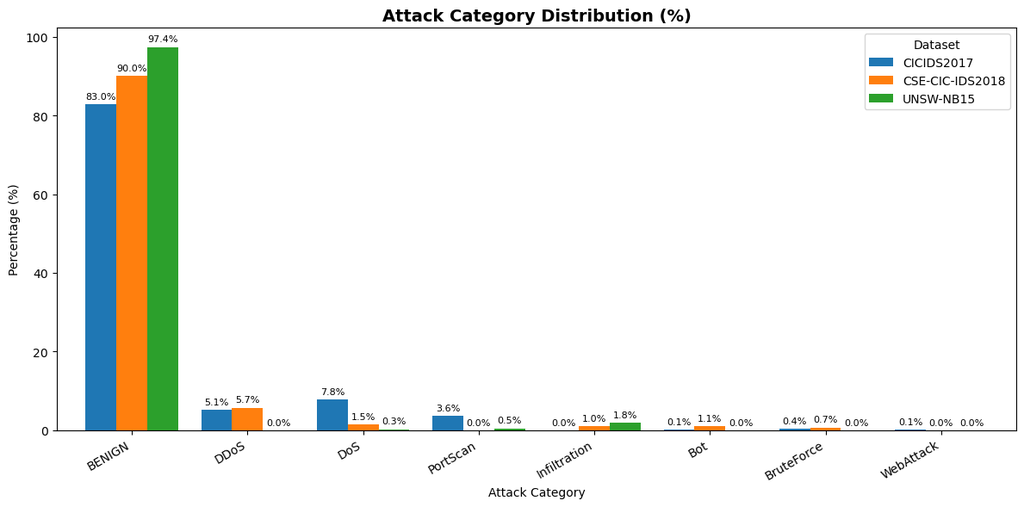

```python
# Plot attack category distribution
def plot_attack_distribution(train_df, test1_df, test2_df):

    # Percentage distribution
    train_pct = train_df["label"].value_counts(normalize=True).mul(100)
    test1_pct = test1_df["label"].value_counts(normalize=True).mul(100)
    test2_pct = test2_df["label"].value_counts(normalize=True).mul(100)

    # Combine into one DataFrame
    dist = pd.concat(
        [train_pct, test1_pct, test2_pct],
        axis=1
    )

    dist.columns = [
        "CICIDS2017",
        "CSE-CIC-IDS2018",
        "UNSW-NB15"
    ]

    # Replace missing attack categories with 0%
    dist = dist.fillna(0)

    # Sort categories by overall percentage (descending)
    dist["Total"] = dist.sum(axis=1)
    dist = dist.sort_values("Total", ascending=False)
    dist = dist.drop(columns="Total")

    # Plot
    ax = dist.plot(
        kind="bar",
        figsize=(12,6),
        width=0.8
    )

    ax.set_title("Attack Category Distribution (%)", fontsize=14, weight="bold")
    ax.set_xlabel("Attack Category")
    ax.set_ylabel("Percentage (%)")
    ax.legend(title="Dataset")
    plt.xticks(rotation=30, ha="right")

    # Percentage labels above bars
    for container in ax.containers:
        ax.bar_label(
            container,
            fmt="%.1f%%",
            fontsize=8,
            padding=3
        )

    plt.tight_layout()
    plt.show()


# Plot
plot_attack_distribution(
    train_df,
    test1_df,
    test2_df
)
```

##### Counts After Mapping Attacks

```python
# Count attacks in each dataset after Handling Infinities, NaNs and Removing Duplicates
train_counts = train_df["label"].value_counts().sort_index()
test1_counts = test1_df["label"].value_counts().sort_index()
test2_counts = test2_df["label"].value_counts().sort_index()

# Combine into one comparison table
attack_counts_df = pd.concat(
    [train_counts, test1_counts, test2_counts],
    axis=1
)

attack_counts_df.columns = ["CICIDS2017 (Train)", "CSE-CIC-IDS2018 (Test1)", "UNSW-NB15 (Test2)"]
attack_counts_df = attack_counts_df.fillna(0).astype(int)

print("Attack Counts After Mapping")
display(attack_counts_df)
```

```
Attack Counts After Mapping
```

| label | CICIDS2017 (Train) | CSE-CIC-IDS2018 (Test1) | UNSW-NB15 (Test2) |
| --- | --- | --- | --- |
| BENIGN | 2073870 | 12196127 | 3389125 |
| Bot | 1953 | 144535 | 0 |
| BruteForce | 9152 | 94655 | 0 |
| DDoS | 128016 | 776782 | 0 |
| DoS | 193748 | 196568 | 9064 |
| Infiltration | 47 | 140612 | 63734 |
| PortScan | 90819 | 0 | 16710 |
| WebAttack | 2143 | 312 | 0 |

##### Saving the newly formed datasets so that we don't have to re-run everything again.

```python
import os
import math

def save_parquet_chunks(df, output_dir, prefix, chunk_size=500_000):
    """
    Save a DataFrame into multiple Parquet files.

    Parameters
    ----------
    df : pandas.DataFrame
    output_dir : str
        Folder to save the chunks.
    prefix : str
        Prefix for chunk filenames.
    chunk_size : int
        Number of rows per chunk.
    """
    os.makedirs(output_dir, exist_ok=True)

    n_chunks = math.ceil(len(df) / chunk_size)

    for i in range(n_chunks):
        start = i * chunk_size
        end = min((i + 1) * chunk_size, len(df))

        chunk = df.iloc[start:end]

        filename = os.path.join(
            output_dir,
            f"{prefix}_part_{i+1:03d}.parquet"
        )

        chunk.to_parquet(filename, index=False)

        print(f"Saved chunk {i+1}/{n_chunks}: {filename} ({len(chunk):,} rows)")

    print(f"\nFinished saving {n_chunks} chunks.")

save_dir = "processed_datasets_chunked_attacks_mapped1"

# CICIDS2017
save_parquet_chunks(
    train_df,
    save_dir,
    "CICIDS2017_train",
    chunk_size=500_000
)

# CSE-CIC-IDS2018
save_parquet_chunks(
    test1_df,
    save_dir,
    "CSE_CIC_IDS2018_test1",
    chunk_size=500_000
)

# UNSW-NB15
save_parquet_chunks(
    test2_df,
    save_dir,
    "UNSW_NB15_test2",
    chunk_size=500_000
)
```

```
Saved chunk 1/5: processed_datasets_chunked_attacks_mapped1\CICIDS2017_train_part_001.parquet (500,000 rows)
Saved chunk 2/5: processed_datasets_chunked_attacks_mapped1\CICIDS2017_train_part_002.parquet (500,000 rows)
Saved chunk 3/5: processed_datasets_chunked_attacks_mapped1\CICIDS2017_train_part_003.parquet (500,000 rows)
Saved chunk 4/5: processed_datasets_chunked_attacks_mapped1\CICIDS2017_train_part_004.parquet (500,000 rows)
Saved chunk 5/5: processed_datasets_chunked_attacks_mapped1\CICIDS2017_train_part_005.parquet (499,748 rows)

Finished saving 5 chunks.
Saved chunk 1/28: processed_datasets_chunked_attacks_mapped1\CSE_CIC_IDS2018_test1_part_001.parquet (500,000 rows)
Saved chunk 2/28: processed_datasets_chunked_attacks_mapped1\CSE_CIC_IDS2018_test1_part_002.parquet (500,000 rows)
Saved chunk 3/28: processed_datasets_chunked_attacks_mapped1\CSE_CIC_IDS2018_test1_part_003.parquet (500,000 rows)
Saved chunk 4/28: processed_datasets_chunked_attacks_mapped1\CSE_CIC_IDS2018_test1_part_004.parquet (500,000 rows)
Saved chunk 5/28: processed_datasets_chunked_attacks_mapped1\CSE_CIC_IDS2018_test1_part_005.parquet (500,000 rows)
Saved chunk 6/28: processed_datasets_chunked_attacks_mapped1\CSE_CIC_IDS2018_test1_part_006.parquet (500,000 rows)
Saved chunk 7/28: processed_datasets_chunked_attacks_mapped1\CSE_CIC_IDS2018_test1_part_007.parquet (500,000 rows)
Saved chunk 8/28: processed_datasets_chunked_attacks_mapped1\CSE_CIC_IDS2018_test1_part_008.parquet (500,000 rows)
Saved chunk 9/28: processed_datasets_chunked_attacks_mapped1\CSE_CIC_IDS2018_test1_part_009.parquet (500,000 rows)
Saved chunk 10/28: processed_datasets_chunked_attacks_mapped1\CSE_CIC_IDS2018_test1_part_010.parquet (500,000 rows)
Saved chunk 11/28: processed_datasets_chunked_attacks_mapped1\CSE_CIC_IDS2018_test1_part_011.parquet (500,000 rows)
Saved chunk 12/28: processed_datasets_chunked_attacks_mapped1\CSE_CIC_IDS2018_test1_part_012.parquet (500,000 rows)
Saved chunk 13/28: processed_datasets_chunked_attacks_mapped1\CSE_CIC_IDS2018_test1_part_013.parquet (500,000 rows)
Saved chunk 14/28: processed_datasets_chunked_attacks_mapped1\CSE_CIC_IDS2018_test1_part_014.parquet (500,000 rows)
Saved chunk 15/28: processed_datasets_chunked_attacks_mapped1\CSE_CIC_IDS2018_test1_part_015.parquet (500,000 rows)
Saved chunk 16/28: processed_datasets_chunked_attacks_mapped1\CSE_CIC_IDS2018_test1_part_016.parquet (500,000 rows)
Saved chunk 17/28: processed_datasets_chunked_attacks_mapped1\CSE_CIC_IDS2018_test1_part_017.parquet (500,000 rows)
Saved chunk 18/28: processed_datasets_chunked_attacks_mapped1\CSE_CIC_IDS2018_test1_part_018.parquet (500,000 rows)
Saved chunk 19/28: processed_datasets_chunked_attacks_mapped1\CSE_CIC_IDS2018_test1_part_019.parquet (500,000 rows)
Saved chunk 20/28: processed_datasets_chunked_attacks_mapped1\CSE_CIC_IDS2018_test1_part_020.parquet (500,000 rows)
Saved chunk 21/28: processed_datasets_chunked_attacks_mapped1\CSE_CIC_IDS2018_test1_part_021.parquet (500,000 rows)
Saved chunk 22/28: processed_datasets_chunked_attacks_mapped1\CSE_CIC_IDS2018_test1_part_022.parquet (500,000 rows)
Saved chunk 23/28: processed_datasets_chunked_attacks_mapped1\CSE_CIC_IDS2018_test1_part_023.parquet (500,000 rows)
Saved chunk 24/28: processed_datasets_chunked_attacks_mapped1\CSE_CIC_IDS2018_test1_part_024.parquet (500,000 rows)
Saved chunk 25/28: processed_datasets_chunked_attacks_mapped1\CSE_CIC_IDS2018_test1_part_025.parquet (500,000 rows)
Saved chunk 26/28: processed_datasets_chunked_attacks_mapped1\CSE_CIC_IDS2018_test1_part_026.parquet (500,000 rows)
Saved chunk 27/28: processed_datasets_chunked_attacks_mapped1\CSE_CIC_IDS2018_test1_part_027.parquet (500,000 rows)
Saved chunk 28/28: processed_datasets_chunked_attacks_mapped1\CSE_CIC_IDS2018_test1_part_028.parquet (49,591 rows)

Finished saving 28 chunks.
Saved chunk 1/7: processed_datasets_chunked_attacks_mapped1\UNSW_NB15_test2_part_001.parquet (500,000 rows)
Saved chunk 2/7: processed_datasets_chunked_attacks_mapped1\UNSW_NB15_test2_part_002.parquet (500,000 rows)
Saved chunk 3/7: processed_datasets_chunked_attacks_mapped1\UNSW_NB15_test2_part_003.parquet (500,000 rows)
Saved chunk 4/7: processed_datasets_chunked_attacks_mapped1\UNSW_NB15_test2_part_004.parquet (500,000 rows)
Saved chunk 5/7: processed_datasets_chunked_attacks_mapped1\UNSW_NB15_test2_part_005.parquet (500,000 rows)
Saved chunk 6/7: processed_datasets_chunked_attacks_mapped1\UNSW_NB15_test2_part_006.parquet (500,000 rows)
Saved chunk 7/7: processed_datasets_chunked_attacks_mapped1\UNSW_NB15_test2_part_007.parquet (478,633 rows)

Finished saving 7 chunks.
```

##### Correlation Heatmap of CICIDS2017

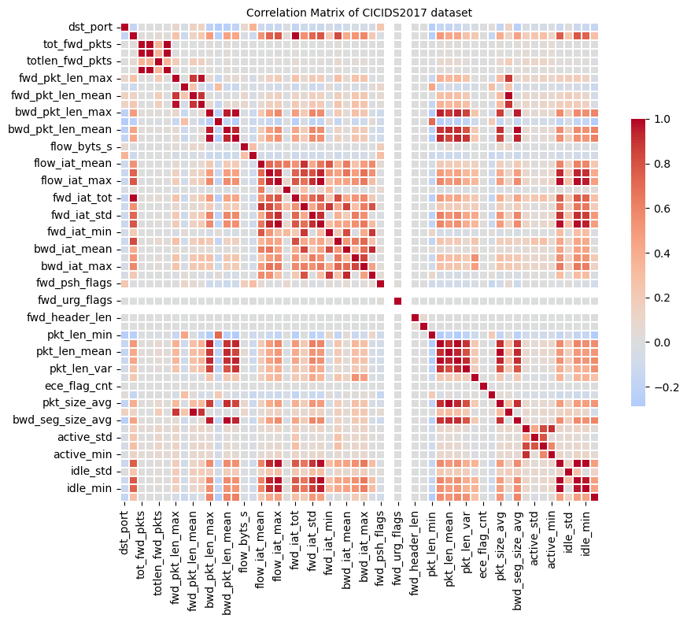

```python
# Exclude target columns
corr_df = train_df.drop(
    columns=["label", "multi_label"], #using binary_label instead of label since it has been mapped to numeric data type.
    errors="ignore"
)

# Keep only numeric columns
corr_df = corr_df.select_dtypes(include=["number"])

# Correlation matrix
corr_matrix = corr_df.corr()

# Plot
plt.figure(figsize=(10, 8))

sns.heatmap(
    corr_matrix,
    cmap="coolwarm",
    center=0,
    square=True,
    linewidths=0.2,
    cbar_kws={"shrink": 0.6}
)

plt.title("Correlation Matrix of CICIDS2017 dataset", fontsize=10)
plt.tight_layout()
plt.show()
```

##### Correlation Heatmap of CSE-CIC-IDS2018

[figure not shown]

```python
# Exclude target columns
corr_df = test1_df.drop(
    columns=["label", "multi_label"], #using binary_label instead of label since it has been mapped to numeric data type.
    errors="ignore"
)

# Keep only numeric columns
corr_df = corr_df.select_dtypes(include=["number"])

# Correlation matrix
corr_matrix = corr_df.corr()

# Plot
plt.figure(figsize=(10, 8))

sns.heatmap(
    corr_matrix,
    cmap="coolwarm",
    center=0,
    square=True,
    linewidths=0.2,
    cbar_kws={"shrink": 0.6}
)

plt.title("Correlation Matrix of CICIDS2017 dataset", fontsize=10)
plt.tight_layout()
plt.show()
```

##### Correlation Heatmap of UNSW-NB15

[figure not shown]

```python
# Exclude target columns
corr_df = test2_df.drop(
    columns=["label", "multi_label"], #using binary_label instead of label since it has been mapped to numeric data type.
    errors="ignore"
)

# Keep only numeric columns
corr_df = corr_df.select_dtypes(include=["number"])

# Correlation matrix
corr_matrix = corr_df.corr()

# Plot
plt.figure(figsize=(10, 8))

sns.heatmap(
    corr_matrix,
    cmap="coolwarm",
    center=0,
    square=True,
    linewidths=0.2,
    cbar_kws={"shrink": 0.6}
)

plt.title("Correlation Matrix of CICIDS2017 dataset", fontsize=10)
plt.tight_layout()
plt.show()
```

##### Skewness Graph of CICIDS2017

```
Total Features: 55
Need Transformation: 53
['fwd_header_len', 'totlen_fwd_pkts', 'bwd_header_len', 'tot_bwd_pkts', 'tot_fwd_pkts', 'totlen_bwd_pkts', 'fwd_urg_flags', 'ece_flag_cnt', 'flow_byts_s', 'active_min', 'active_std', 'active_mean', 'flow_iat_min', 'active_max', 'fwd_pkt_len_min', 'down_up_ratio', 'pkt_len_min', 'fwd_pkt_len_std', 'i…
```

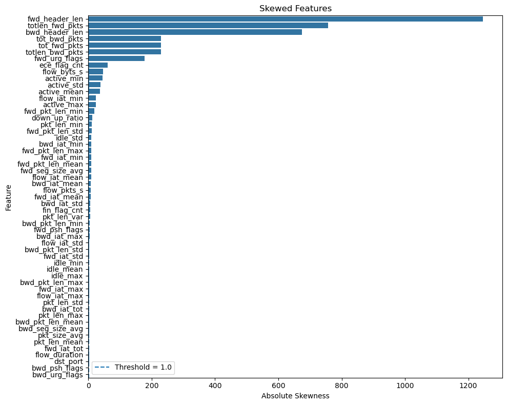

```python
#Use numeric features only
num_df = (
    train_df
    .drop(columns=["label", "multi_label"], errors="ignore")
    .select_dtypes(include=np.number)
)

#exclude binary_label
num_df = num_df.drop(columns=["binary_label"], errors="ignore")

#Calculate Skewness
skewness = num_df.skew()

skew_df = pd.DataFrame({
    "feature": skewness.index,
    "skewness": skewness.values,
    "abs_skewness": skewness.abs().values
})

skew_df = skew_df.sort_values(
    "abs_skewness",
    ascending=False
)

#Features that require transformation
threshold = 1.0

transform_features = skew_df[
    skew_df["abs_skewness"] > threshold
]

print(f"\nTotal Features: {len(skew_df)}")
print(f"Need Transformation: {len(transform_features)}")

features_to_transform = transform_features["feature"].tolist()

print(features_to_transform)

#Skewness Plot
plt.figure(figsize=(10, 8))

sns.barplot(
    data=skew_df,
    x="abs_skewness",
    y="feature"
)

plt.axvline(
    threshold,
    linestyle="--",
    label=f"Threshold = {threshold}"
)

plt.title("Skewed Features")
plt.xlabel("Absolute Skewness")
plt.ylabel("Feature")
plt.legend()

plt.tight_layout()
plt.show()
```

##### Skewness Graph of CSE-CIC-IDS2018

```
Total Features: 55
Need Transformation: 53
['flow_iat_mean', 'fwd_iat_mean', 'idle_min', 'pkt_len_var', 'fwd_iat_tot', 'flow_duration', 'idle_max', 'idle_std', 'idle_mean', 'flow_iat_std', 'fwd_iat_std', 'flow_iat_min', 'fwd_iat_min', 'fwd_iat_max', 'flow_iat_max', 'totlen_fwd_pkts', 'tot_bwd_pkts', 'bwd_header_len', 'totlen_bwd_pkts', 'down…
```

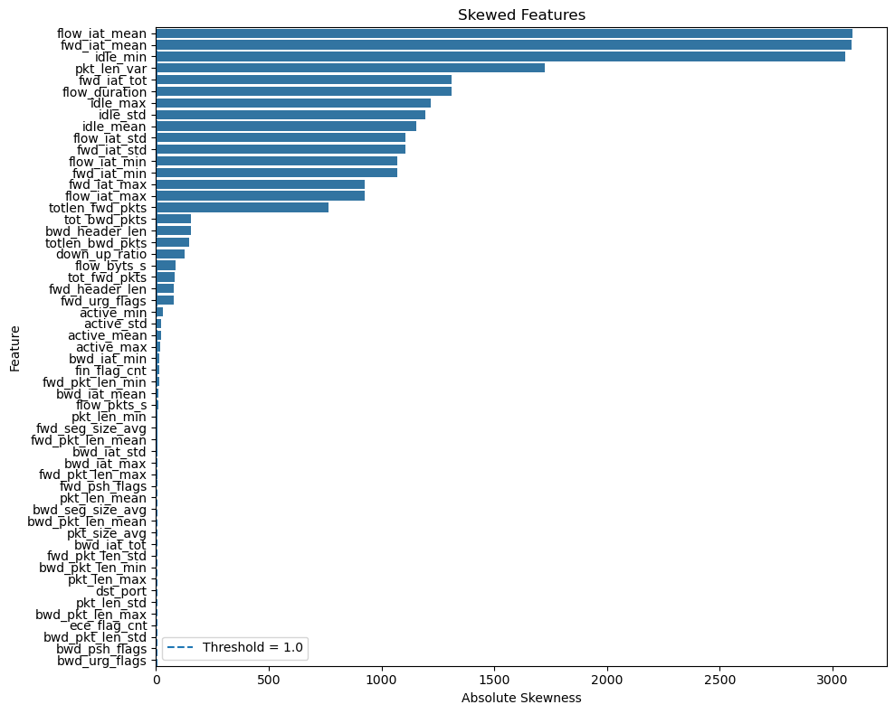

```python
#Use numeric features only
num_df = (
    test1_df
    .drop(columns=["label", "multi_label"], errors="ignore")
    .select_dtypes(include=np.number)
)

#exclude binary_label
num_df = num_df.drop(columns=["binary_label"], errors="ignore")

#Calculate Skewness
skewness = num_df.skew()

skew_df = pd.DataFrame({
    "feature": skewness.index,
    "skewness": skewness.values,
    "abs_skewness": skewness.abs().values
})

skew_df = skew_df.sort_values(
    "abs_skewness",
    ascending=False
)

#Features that require transformation
threshold = 1.0

transform_features = skew_df[
    skew_df["abs_skewness"] > threshold
]

print(f"\nTotal Features: {len(skew_df)}")
print(f"Need Transformation: {len(transform_features)}")

features_to_transform = transform_features["feature"].tolist()

print(features_to_transform)

#Skewness Plot
plt.figure(figsize=(10, 8))

sns.barplot(
    data=skew_df,
    x="abs_skewness",
    y="feature"
)

plt.axvline(
    threshold,
    linestyle="--",
    label=f"Threshold = {threshold}"
)

plt.title("Skewed Features")
plt.xlabel("Absolute Skewness")
plt.ylabel("Feature")
plt.legend()

plt.tight_layout()
plt.show()
```

##### Skewness Graph of UNSW-NB15

```
Total Features: 55
Need Transformation: 47
['bwd_iat_min', 'flow_iat_min', 'fwd_iat_min', 'idle_std', 'totlen_fwd_pkts', 'active_min', 'down_up_ratio', 'active_std', 'active_mean', 'flow_iat_mean', 'active_max', 'bwd_iat_mean', 'fwd_iat_mean', 'bwd_iat_std', 'flow_iat_std', 'fwd_iat_std', 'tot_fwd_pkts', 'idle_min', 'idle_mean', 'idle_max', …
```

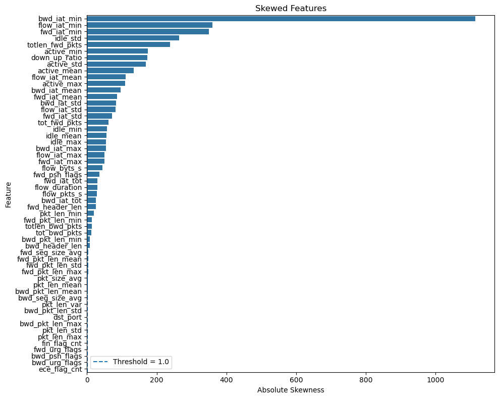

```python
#Use numeric features only
num_df = (
    test2_df
    .drop(columns=["label", "multi_label"], errors="ignore")
    .select_dtypes(include=np.number)
)

#exclude binary_label
num_df = num_df.drop(columns=["binary_label"], errors="ignore")

#Calculate Skewness
skewness = num_df.skew()

skew_df = pd.DataFrame({
    "feature": skewness.index,
    "skewness": skewness.values,
    "abs_skewness": skewness.abs().values
})

skew_df = skew_df.sort_values(
    "abs_skewness",
    ascending=False
)

#Features that require transformation
threshold = 1.0

transform_features = skew_df[
    skew_df["abs_skewness"] > threshold
]

print(f"\nTotal Features: {len(skew_df)}")
print(f"Need Transformation: {len(transform_features)}")

features_to_transform = transform_features["feature"].tolist()

print(features_to_transform)

#Skewness Plot
plt.figure(figsize=(10, 8))

sns.barplot(
    data=skew_df,
    x="abs_skewness",
    y="feature"
)

plt.axvline(
    threshold,
    linestyle="--",
    label=f"Threshold = {threshold}"
)

plt.title("Skewed Features")
plt.xlabel("Absolute Skewness")
plt.ylabel("Feature")
plt.legend()

plt.tight_layout()
plt.show()
```

#### Training the Supervised Learning Models

We will use train CICIDS2017 dataset (100%) and test it on CSE-CIC-IDS2018 (100%) and UNSW-NB15 (100%).

1. Random Forest
2. XG Boost
3. Deep Neural Network

Binary Labels:

1. 0 → Benign
2. 1 → Attack

Since our purpose is to analyze which model performs better in predicting the attacks, we have set our target to 'binary_label'.

```python
# Dropping columns
DROP_COLS = ['label', 'binary_label', 'multi_label']

# CICIDS2017 Training dataset
X_train_df = train_df.drop(columns=DROP_COLS)

# Save feature names (only once from the training set)
feature_names = X_train_df.columns.tolist()

X_train = X_train_df.to_numpy(dtype=np.float32)
y_train = train_df['binary_label'].to_numpy(dtype=np.int8)

# Free memory
del X_train_df
gc.collect()

# CSE-CIC-IDS2018 Test1 dataset
X_test1_df = test1_df.drop(columns=DROP_COLS)

X_test1 = X_test1_df.to_numpy(dtype=np.float32)
y_test1 = test1_df['binary_label'].to_numpy(dtype=np.int8)

# Free memory
del X_test1_df
gc.collect()

# UNSW-NB15 Test2 dataset
X_test2_df = test2_df.drop(columns=DROP_COLS)

X_test2 = X_test2_df.to_numpy(dtype=np.float32)
y_test2 = test2_df['binary_label'].to_numpy(dtype=np.int8)

# Free memory
del X_test2_df
gc.collect()
```

```
0
```

```python
# No SMOTE and Scaling for Random Forest & XGBoost

X_train_tree = X_train
X_test1_tree = X_test1
X_test2_tree = X_test2

y_train_tree = y_train
y_test1_tree = y_test1
y_test2_tree = y_test2


# Deep Neural Network (Scaling Only)

scaler = RobustScaler()

# Fit only on training data
X_train_dnn = scaler.fit_transform(X_train)

# Transform test datasets
X_test1_dnn = scaler.transform(X_test1)
X_test2_dnn = scaler.transform(X_test2)

y_train_dnn = y_train
y_test1_dnn = y_test1
y_test2_dnn = y_test2

# Free memory if the original arrays are no longer needed
del X_train, X_test1, X_test2
gc.collect()
```

```
0
```

#### Training the Supervised Learning Models

##### Function to evaluate the models for binary labels

```python
def evaluate_model(name, model, X_test, y_test, dataset_name, is_keras=False):

    if is_keras:
        y_prob = model.predict(X_test, verbose=0).ravel()
        y_pred = (y_prob >= 0.5).astype(int)
    else:
        y_pred = model.predict(X_test)
        if hasattr(model, "predict_proba"):
            y_prob = model.predict_proba(X_test)[:, 1]
        else:
            y_prob = model.decision_function(X_test)

    # Evaluation metrics
    accuracy = accuracy_score(y_test, y_pred)
    precision = precision_score(y_test, y_pred, zero_division=0)
    recall = recall_score(y_test, y_pred, zero_division=0)
    f1 = f1_score(y_test, y_pred, zero_division=0) #Focuses on how well the model performs in identifying Attacks.
    f1_macro = f1_score(y_test, y_pred, average="macro", zero_division=0) #Shows the overall performance of detection
    mcc = matthews_corrcoef(y_test, y_pred)  #Mathews Correlation Coefficient penalizes biased predictions and handles class imbalance better. Better evaluation metric than F1 score in terms of detecting Attack vs Benign
    auc = roc_auc_score(y_test, y_prob)

    # Print results
    print(f"{name} → {dataset_name}")
    print("*" * 30)
    print(f"Accuracy      : {accuracy:.4f}")
    print(f"Precision     : {precision:.4f}")
    print(f"Recall        : {recall:.4f}")
    print(f"F1-score      : {f1:.4f}")
    print(f"Macro F1      : {f1_macro:.4f}")
    print(f"MCC           : {mcc:.4f}")
    print(f"ROC-AUC       : {auc:.4f}")
    print()
    print(classification_report(
        y_test, y_pred,
        target_names=['Benign', 'Attack']
    ))

    #Confusion matrix
    cm   = confusion_matrix(y_test, y_pred)
    disp = ConfusionMatrixDisplay(cm, display_labels=['Benign', 'Attack'])
    disp.plot(cmap="Blues")
    plt.title(f"{name} — {dataset_name}")
    plt.tight_layout()
    plt.show()

    return {
        "Model": name,
        "Test Dataset": dataset_name,
        "Accuracy": round(accuracy, 3),
        "Precision": round(precision, 3),
        "Recall": round(recall, 3),
        "F1-score": round(f1, 3),
        "Macro F1": round(f1_macro, 3),
        "ROC-AUC": round(auc, 3),
        "MCC": round(mcc, 3),
    }
```

```python
#TUNING SUBSET

TUNING_SIZE = 300000

X_tune, _, y_tune, _ = train_test_split(
    X_train_tree,
    y_train_tree,
    train_size=TUNING_SIZE,
    stratify=y_train_tree,
    random_state=42
)

X_tune_train, X_tune_val, y_tune_train, y_tune_val = train_test_split(
    X_tune,
    y_tune,
    test_size=0.20,
    stratify=y_tune,
    random_state=42
)

print("Tuning training shape:", X_tune_train.shape)
print("Tuning validation shape:", X_tune_val.shape)
```

```
Tuning training shape: (240000, 55)
Tuning validation shape: (60000, 55)
```

##### Training Random Forest

```python
# OPTUNA - RANDOM FOREST (F1 OPTIMIZATION)

def rf_objective(trial):

    params = {
        "n_estimators": trial.suggest_int(
            "n_estimators", 100, 200, step=100
        ),

        "max_depth": trial.suggest_int(
            "max_depth", 8, 10, step=2
        ),

        "min_samples_leaf": trial.suggest_int(
            "min_samples_leaf", 2, 4, step=2
        ),

        "max_features": trial.suggest_categorical(
            "max_features",
            ["sqrt", "log2"]
        ),

        "min_samples_split": 2,
        "bootstrap": True,
        "criterion": "gini",
        "class_weight": "balanced",
        "n_jobs": -1,
        "random_state": 42
    }

    model = RandomForestClassifier(**params)

    model.fit(
        X_tune_train,
        y_tune_train
    )

    y_pred = model.predict(X_tune_val)

    # F1-score for Attack class
    f1 = f1_score(
        y_tune_val,
        y_pred,
        zero_division=0
    )

    return f1
```

```python
# CREATE RANDOM FOREST OPTUNA STUDY

rf_study = optuna.create_study(
    direction="maximize",
    study_name="RandomForest_F1"
)

for _ in tqdm(range(30), desc="Optuna RF Trials"):
    rf_study.optimize(
        rf_objective,
        n_trials=1,
        n_jobs=1,
        show_progress_bar=True
    )

print("\nBest Random Forest F1:")
print(round(rf_study.best_value, 3))

print("\nBest Random Forest parameters:")
print(rf_study.best_params)
```

```
[I 2026-09-12 16:30:32,950] A new study created in memory with name: RandomForest_F1
```

```
[I 2026-09-12 16:30:56,992] Trial 0 finished with value: 0.9851637859276307 and parameters: {'n_estimators': 200, 'max_depth': 8, 'min_samples_leaf': 4, 'max_features': 'sqrt'}. Best is trial 0 with value: 0.9851637859276307.
```

```
[I 2026-09-12 16:31:20,539] Trial 1 finished with value: 0.9863738849132438 and parameters: {'n_estimators': 200, 'max_depth': 8, 'min_samples_leaf': 2, 'max_features': 'sqrt'}. Best is trial 1 with value: 0.9863738849132438.
```

```
[I 2026-09-12 16:31:44,559] Trial 2 finished with value: 0.9851637859276307 and parameters: {'n_estimators': 200, 'max_depth': 8, 'min_samples_leaf': 4, 'max_features': 'sqrt'}. Best is trial 1 with value: 0.9863738849132438.
```

```
[I 2026-09-12 16:32:04,320] Trial 3 finished with value: 0.9902513104394258 and parameters: {'n_estimators': 200, 'max_depth': 10, 'min_samples_leaf': 2, 'max_features': 'log2'}. Best is trial 3 with value: 0.9902513104394258.
```

```
[I 2026-09-12 16:32:23,785] Trial 4 finished with value: 0.9901087062971305 and parameters: {'n_estimators': 200, 'max_depth': 10, 'min_samples_leaf': 4, 'max_features': 'log2'}. Best is trial 3 with value: 0.9902513104394258.
```

```
[I 2026-09-12 16:32:43,095] Trial 5 finished with value: 0.9901087062971305 and parameters: {'n_estimators': 200, 'max_depth': 10, 'min_samples_leaf': 4, 'max_features': 'log2'}. Best is trial 3 with value: 0.9902513104394258.
```

```
[I 2026-09-12 16:32:52,486] Trial 6 finished with value: 0.9834118570867687 and parameters: {'n_estimators': 100, 'max_depth': 8, 'min_samples_leaf': 4, 'max_features': 'log2'}. Best is trial 3 with value: 0.9902513104394258.
```

```
[I 2026-09-12 16:33:12,137] Trial 7 finished with value: 0.9902513104394258 and parameters: {'n_estimators': 200, 'max_depth': 10, 'min_samples_leaf': 2, 'max_features': 'log2'}. Best is trial 3 with value: 0.9902513104394258.
```

```
[I 2026-09-12 16:33:29,472] Trial 8 finished with value: 0.985544176018033 and parameters: {'n_estimators': 200, 'max_depth': 8, 'min_samples_leaf': 4, 'max_features': 'log2'}. Best is trial 3 with value: 0.9902513104394258.
```

```
[I 2026-09-12 16:33:43,221] Trial 9 finished with value: 0.9905125195618153 and parameters: {'n_estimators': 100, 'max_depth': 10, 'min_samples_leaf': 4, 'max_features': 'sqrt'}. Best is trial 9 with value: 0.9905125195618153.
```

```
[I 2026-09-12 16:33:57,675] Trial 10 finished with value: 0.9909019761299158 and parameters: {'n_estimators': 100, 'max_depth': 10, 'min_samples_leaf': 2, 'max_features': 'sqrt'}. Best is trial 10 with value: 0.9909019761299158.
```

```
[I 2026-09-12 16:34:11,761] Trial 11 finished with value: 0.9909019761299158 and parameters: {'n_estimators': 100, 'max_depth': 10, 'min_samples_leaf': 2, 'max_features': 'sqrt'}. Best is trial 10 with value: 0.9909019761299158.
```

```
[I 2026-09-12 16:34:25,801] Trial 12 finished with value: 0.9909019761299158 and parameters: {'n_estimators': 100, 'max_depth': 10, 'min_samples_leaf': 2, 'max_features': 'sqrt'}. Best is trial 10 with value: 0.9909019761299158.
```

```
[I 2026-09-12 16:34:39,578] Trial 13 finished with value: 0.9909019761299158 and parameters: {'n_estimators': 100, 'max_depth': 10, 'min_samples_leaf': 2, 'max_features': 'sqrt'}. Best is trial 10 with value: 0.9909019761299158.
```

```
[I 2026-09-12 16:34:53,430] Trial 14 finished with value: 0.9909019761299158 and parameters: {'n_estimators': 100, 'max_depth': 10, 'min_samples_leaf': 2, 'max_features': 'sqrt'}. Best is trial 10 with value: 0.9909019761299158.
```

```
[I 2026-09-12 16:35:07,543] Trial 15 finished with value: 0.9909019761299158 and parameters: {'n_estimators': 100, 'max_depth': 10, 'min_samples_leaf': 2, 'max_features': 'sqrt'}. Best is trial 10 with value: 0.9909019761299158.
```

```
[I 2026-09-12 16:35:21,672] Trial 16 finished with value: 0.9909019761299158 and parameters: {'n_estimators': 100, 'max_depth': 10, 'min_samples_leaf': 2, 'max_features': 'sqrt'}. Best is trial 10 with value: 0.9909019761299158.
```

```
[I 2026-09-12 16:35:35,744] Trial 17 finished with value: 0.9909019761299158 and parameters: {'n_estimators': 100, 'max_depth': 10, 'min_samples_leaf': 2, 'max_features': 'sqrt'}. Best is trial 10 with value: 0.9909019761299158.
```

```
[I 2026-09-12 16:35:49,742] Trial 18 finished with value: 0.9909019761299158 and parameters: {'n_estimators': 100, 'max_depth': 10, 'min_samples_leaf': 2, 'max_features': 'sqrt'}. Best is trial 10 with value: 0.9909019761299158.
```

```
[I 2026-09-12 16:36:03,891] Trial 19 finished with value: 0.9909019761299158 and parameters: {'n_estimators': 100, 'max_depth': 10, 'min_samples_leaf': 2, 'max_features': 'sqrt'}. Best is trial 10 with value: 0.9909019761299158.
```

```
[I 2026-09-12 16:36:16,270] Trial 20 finished with value: 0.9860383089207858 and parameters: {'n_estimators': 100, 'max_depth': 8, 'min_samples_leaf': 2, 'max_features': 'sqrt'}. Best is trial 10 with value: 0.9909019761299158.
```

```
[I 2026-09-12 16:36:30,722] Trial 21 finished with value: 0.9909019761299158 and parameters: {'n_estimators': 100, 'max_depth': 10, 'min_samples_leaf': 2, 'max_features': 'sqrt'}. Best is trial 10 with value: 0.9909019761299158.
```

```
[I 2026-09-12 16:36:44,771] Trial 22 finished with value: 0.9909019761299158 and parameters: {'n_estimators': 100, 'max_depth': 10, 'min_samples_leaf': 2, 'max_features': 'sqrt'}. Best is trial 10 with value: 0.9909019761299158.
```

```
[I 2026-09-12 16:36:59,105] Trial 23 finished with value: 0.9909019761299158 and parameters: {'n_estimators': 100, 'max_depth': 10, 'min_samples_leaf': 2, 'max_features': 'sqrt'}. Best is trial 10 with value: 0.9909019761299158.
```

```
[I 2026-09-12 16:37:13,522] Trial 24 finished with value: 0.9909019761299158 and parameters: {'n_estimators': 100, 'max_depth': 10, 'min_samples_leaf': 2, 'max_features': 'sqrt'}. Best is trial 10 with value: 0.9909019761299158.
```

```
[I 2026-09-12 16:37:27,657] Trial 25 finished with value: 0.9909019761299158 and parameters: {'n_estimators': 100, 'max_depth': 10, 'min_samples_leaf': 2, 'max_features': 'sqrt'}. Best is trial 10 with value: 0.9909019761299158.
```

```
[I 2026-09-12 16:37:41,689] Trial 26 finished with value: 0.9909019761299158 and parameters: {'n_estimators': 100, 'max_depth': 10, 'min_samples_leaf': 2, 'max_features': 'sqrt'}. Best is trial 10 with value: 0.9909019761299158.
```

```
[I 2026-09-12 16:37:55,622] Trial 27 finished with value: 0.9909019761299158 and parameters: {'n_estimators': 100, 'max_depth': 10, 'min_samples_leaf': 2, 'max_features': 'sqrt'}. Best is trial 10 with value: 0.9909019761299158.
```

```
[I 2026-09-12 16:38:09,386] Trial 28 finished with value: 0.9909019761299158 and parameters: {'n_estimators': 100, 'max_depth': 10, 'min_samples_leaf': 2, 'max_features': 'sqrt'}. Best is trial 10 with value: 0.9909019761299158.
```

```
[I 2026-09-12 16:38:21,202] Trial 29 finished with value: 0.9860383089207858 and parameters: {'n_estimators': 100, 'max_depth': 8, 'min_samples_leaf': 2, 'max_features': 'sqrt'}. Best is trial 10 with value: 0.9909019761299158.

Best Random Forest F1:
0.991

Best Random Forest parameters:
{'n_estimators': 100, 'max_depth': 10, 'min_samples_leaf': 2, 'max_features': 'sqrt'}
```

```python
# FINAL RANDOM FOREST

best_rf_params = rf_study.best_params.copy()

best_rf_params.update({
    "bootstrap": True,
    "criterion": "gini",
    "n_jobs": -1,
    "random_state": 42
})

rf_final = RandomForestClassifier(
    **best_rf_params
)

print("Training final Random Forest...")

rf_final.fit(
    X_train_tree,
    y_train_tree
)

print("Final Random Forest training completed.")
```

```
Training final Random Forest...
Final Random Forest training completed.
```

Storing the results for models

```python
results = []
```

##### Random Forest Evaluation

```
Random Forest → CSE-CIC-IDS2018
Accuracy      : 0.9163
Precision     : 0.9553
Recall        : 0.1696
F1-score      : 0.2881
Macro F1      : 0.6218
MCC           : 0.3833
ROC-AUC       : 0.8490

              precision    recall  f1-score   support

      Benign       0.92      1.00      0.96  12196127
      Attack       0.96      0.17      0.29   1353464

    accuracy                           0.92  13549591
   macro avg       0.94      0.58      0.62  13549591
weighted avg       0.92      0.92      0.89  13549591
```

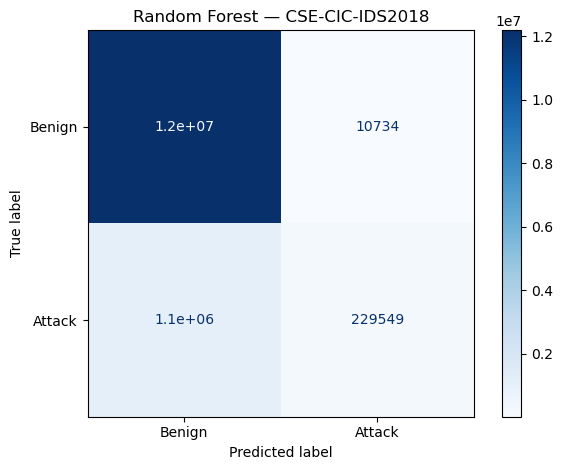

```
Random Forest → UNSW-NB15
Accuracy      : 0.9743
Precision     : 0.3333
Recall        : 0.0002
F1-score      : 0.0003
Macro F1      : 0.4936
MCC           : 0.0068
ROC-AUC       : 0.7005

              precision    recall  f1-score   support

      Benign       0.97      1.00      0.99   3389125
      Attack       0.33      0.00      0.00     89508

    accuracy                           0.97   3478633
   macro avg       0.65      0.50      0.49   3478633
weighted avg       0.96      0.97      0.96   3478633
```

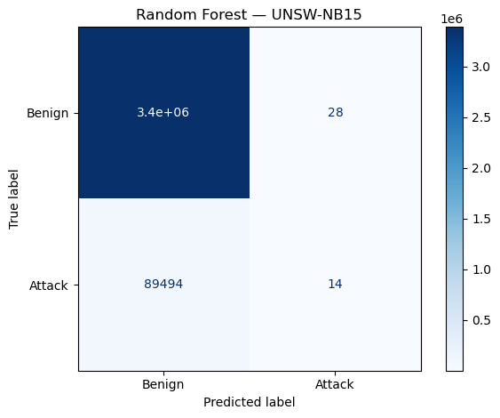

```python
results.append(evaluate_model("Random Forest", rf_final, X_test1_tree, y_test1_tree, "CSE-CIC-IDS2018"))
results.append(evaluate_model("Random Forest", rf_final, X_test2_tree, y_test2_tree, "UNSW-NB15"))
```

##### Training XGBoost

```python
# OPTUNA - XGBOOST (F1 OPTIMIZATION)

# Calculate scale_pos_weight
neg = (y_train_tree == 0).sum()
pos = (y_train_tree == 1).sum()

scale_pos_weight = neg / pos

def xgb_objective(trial):

    params = {
        "n_estimators": trial.suggest_int(
            "n_estimators", 100, 200, step=50
        ),

        "max_depth": trial.suggest_int(
            "max_depth", 4, 6, step=2
        ),

        "learning_rate": trial.suggest_float(
            "learning_rate", 0.1, 0.5,   log=True
        ),

        "subsample": trial.suggest_float(
            "subsample", 0.6, 1.0
        ),

        "colsample_bytree": trial.suggest_float(
            "colsample_bytree", 0.6, 1.0
        ),

        "scale_pos_weight": scale_pos_weight,
        "objective": "binary:logistic",
        "eval_metric": "logloss",
        "tree_method": "hist",
        "random_state": 42,
        "n_jobs": -1
    }

    model = XGBClassifier(**params)

    model.fit(
        X_tune_train,
        y_tune_train
    )

    y_pred = model.predict(X_tune_val)

    # F1-score for Attack class
    f1 = f1_score(
        y_tune_val,
        y_pred,
        zero_division=0
    )

    return f1
```

```python
# CREATE XGBOOST OPTUNA STUDY

xgb_study = optuna.create_study(
    direction="maximize",
    study_name="XGBoost_F1"
)

for _ in tqdm(range(30), desc="Optuna XGBoost Trials"):
    xgb_study.optimize(
        xgb_objective,
        n_trials=1,
        n_jobs=-1,
        show_progress_bar=True
    )

print("\nBest XGBoost F1:")
print(round(xgb_study.best_value, 3))

print("\nBest XGBoost parameters:")
print(xgb_study.best_params)
```

```
[I 2026-09-12 16:43:02,205] A new study created in memory with name: XGBoost_F1
```

```
[I 2026-09-12 16:43:04,747] Trial 0 finished with value: 0.9887345828882199 and parameters: {'n_estimators': 100, 'max_depth': 4, 'learning_rate': 0.12226292387862556, 'subsample': 0.9819432685279053, 'colsample_bytree': 0.893015461223969}. Best is trial 0 with value: 0.9887345828882199.
```

```
[I 2026-09-12 16:43:08,328] Trial 1 finished with value: 0.9924482338611449 and parameters: {'n_estimators': 200, 'max_depth': 4, 'learning_rate': 0.2364019899797473, 'subsample': 0.7359612840685829, 'colsample_bytree': 0.6372681337820821}. Best is trial 1 with value: 0.9924482338611449.
```

```
[I 2026-09-12 16:43:13,237] Trial 2 finished with value: 0.9924856055430857 and parameters: {'n_estimators': 200, 'max_depth': 6, 'learning_rate': 0.3041263056487703, 'subsample': 0.7521912646768849, 'colsample_bytree': 0.6236809538064226}. Best is trial 2 with value: 0.9924856055430857.
```

```
[I 2026-09-12 16:43:16,862] Trial 3 finished with value: 0.9923954372623575 and parameters: {'n_estimators': 150, 'max_depth': 6, 'learning_rate': 0.11772927377116034, 'subsample': 0.6903440543380016, 'colsample_bytree': 0.6137265704964763}. Best is trial 2 with value: 0.9924856055430857.
```

```
[I 2026-09-12 16:43:20,334] Trial 4 finished with value: 0.9924393932003317 and parameters: {'n_estimators': 150, 'max_depth': 6, 'learning_rate': 0.19165780549782818, 'subsample': 0.7285658740133045, 'colsample_bytree': 0.8325253404198095}. Best is trial 2 with value: 0.9924856055430857.
```

```
[I 2026-09-12 16:43:23,894] Trial 5 finished with value: 0.9923961785923182 and parameters: {'n_estimators': 200, 'max_depth': 4, 'learning_rate': 0.23860262141587327, 'subsample': 0.7164134386669628, 'colsample_bytree': 0.6477830615088148}. Best is trial 2 with value: 0.9924856055430857.
```

```
[I 2026-09-12 16:43:26,338] Trial 6 finished with value: 0.9928289184838285 and parameters: {'n_estimators': 100, 'max_depth': 6, 'learning_rate': 0.26289765629969075, 'subsample': 0.7842221008719635, 'colsample_bytree': 0.7067648029701266}. Best is trial 6 with value: 0.9928289184838285.
```

```
[I 2026-09-12 16:43:31,358] Trial 7 finished with value: 0.9922457937088515 and parameters: {'n_estimators': 200, 'max_depth': 6, 'learning_rate': 0.13741067401269555, 'subsample': 0.6094578053173025, 'colsample_bytree': 0.9859420279117712}. Best is trial 6 with value: 0.9928289184838285.
```

```
[I 2026-09-12 16:43:36,204] Trial 8 finished with value: 0.9927783741582902 and parameters: {'n_estimators': 200, 'max_depth': 6, 'learning_rate': 0.43795158824759545, 'subsample': 0.7200979056393997, 'colsample_bytree': 0.717865531243594}. Best is trial 6 with value: 0.9928289184838285.
```

```
[I 2026-09-12 16:43:39,555] Trial 9 finished with value: 0.9922503289954672 and parameters: {'n_estimators': 150, 'max_depth': 6, 'learning_rate': 0.11445086571519168, 'subsample': 0.9316588283507143, 'colsample_bytree': 0.8547286113301066}. Best is trial 6 with value: 0.9928289184838285.
```

```
[I 2026-09-12 16:43:41,575] Trial 10 finished with value: 0.9921566717006869 and parameters: {'n_estimators': 100, 'max_depth': 4, 'learning_rate': 0.4051830276637708, 'subsample': 0.8582622704433683, 'colsample_bytree': 0.75679715043089}. Best is trial 6 with value: 0.9928289184838285.
```

```
[I 2026-09-12 16:43:44,309] Trial 11 finished with value: 0.9925831950814873 and parameters: {'n_estimators': 100, 'max_depth': 6, 'learning_rate': 0.45485753519051375, 'subsample': 0.8244122289379608, 'colsample_bytree': 0.7185722116536709}. Best is trial 6 with value: 0.9928289184838285.
```

```
[I 2026-09-12 16:43:48,171] Trial 12 finished with value: 0.9924885377036387 and parameters: {'n_estimators': 150, 'max_depth': 6, 'learning_rate': 0.32508206789209926, 'subsample': 0.8142943781369792, 'colsample_bytree': 0.7421048817673318}. Best is trial 6 with value: 0.9928289184838285.
```

```
[I 2026-09-12 16:43:50,848] Trial 13 finished with value: 0.9924379177440601 and parameters: {'n_estimators': 100, 'max_depth': 6, 'learning_rate': 0.3458102147409038, 'subsample': 0.6312168028840891, 'colsample_bytree': 0.7049112750561243}. Best is trial 6 with value: 0.9928289184838285.
```

```
[I 2026-09-12 16:43:54,439] Trial 14 finished with value: 0.9925882582406865 and parameters: {'n_estimators': 150, 'max_depth': 6, 'learning_rate': 0.18250293151656888, 'subsample': 0.7945804373930115, 'colsample_bytree': 0.8050104953560537}. Best is trial 6 with value: 0.9928289184838285.
```

```
[I 2026-09-12 16:43:57,000] Trial 15 finished with value: 0.9924863387978142 and parameters: {'n_estimators': 100, 'max_depth': 6, 'learning_rate': 0.2639827605488022, 'subsample': 0.6699439849926253, 'colsample_bytree': 0.6804072253695495}. Best is trial 6 with value: 0.9928289184838285.
```

```
[I 2026-09-12 16:44:01,980] Trial 16 finished with value: 0.9924870719094546 and parameters: {'n_estimators': 200, 'max_depth': 6, 'learning_rate': 0.40588114568744726, 'subsample': 0.8764981840781243, 'colsample_bytree': 0.7769650782084669}. Best is trial 6 with value: 0.9928289184838285.
```

```
[I 2026-09-12 16:44:05,035] Trial 17 finished with value: 0.9927840078010727 and parameters: {'n_estimators': 150, 'max_depth': 4, 'learning_rate': 0.49700394929929653, 'subsample': 0.7722772926085237, 'colsample_bytree': 0.6786339290378234}. Best is trial 6 with value: 0.9928289184838285.
```

```
[I 2026-09-12 16:44:07,925] Trial 18 finished with value: 0.9925889809848855 and parameters: {'n_estimators': 150, 'max_depth': 4, 'learning_rate': 0.49632863795182364, 'subsample': 0.7751040692050241, 'colsample_bytree': 0.6676027997970256}. Best is trial 6 with value: 0.9928289184838285.
```

```
[I 2026-09-12 16:44:10,024] Trial 19 finished with value: 0.9899922269724057 and parameters: {'n_estimators': 100, 'max_depth': 4, 'learning_rate': 0.16274509790416525, 'subsample': 0.8738676129892468, 'colsample_bytree': 0.9150879123594513}. Best is trial 6 with value: 0.9928289184838285.
```

```
[I 2026-09-12 16:44:12,831] Trial 20 finished with value: 0.9918675432188946 and parameters: {'n_estimators': 150, 'max_depth': 4, 'learning_rate': 0.2768293264150368, 'subsample': 0.9269357045357989, 'colsample_bytree': 0.7841765412103219}. Best is trial 6 with value: 0.9928289184838285.
```

```
[I 2026-09-12 16:44:16,730] Trial 21 finished with value: 0.9926829268292683 and parameters: {'n_estimators': 200, 'max_depth': 4, 'learning_rate': 0.410742024907851, 'subsample': 0.6716446218216099, 'colsample_bytree': 0.7079447373918769}. Best is trial 6 with value: 0.9928289184838285.
```

```
[I 2026-09-12 16:44:20,713] Trial 22 finished with value: 0.9924393932003317 and parameters: {'n_estimators': 150, 'max_depth': 6, 'learning_rate': 0.3614378380288631, 'subsample': 0.7714739247472282, 'colsample_bytree': 0.6812854999179089}. Best is trial 6 with value: 0.9928289184838285.
```

```
[I 2026-09-12 16:44:25,499] Trial 23 finished with value: 0.9927769643728648 and parameters: {'n_estimators': 200, 'max_depth': 6, 'learning_rate': 0.49683355561255166, 'subsample': 0.8342232436884238, 'colsample_bytree': 0.7367331790253373}. Best is trial 6 with value: 0.9928289184838285.
```

```
[I 2026-09-12 16:44:27,535] Trial 24 finished with value: 0.9912331969608417 and parameters: {'n_estimators': 100, 'max_depth': 4, 'learning_rate': 0.3737835476476651, 'subsample': 0.6997331565922098, 'colsample_bytree': 0.6672159050117645}. Best is trial 6 with value: 0.9928289184838285.
```

```
[I 2026-09-12 16:44:31,353] Trial 25 finished with value: 0.9924371797999512 and parameters: {'n_estimators': 150, 'max_depth': 6, 'learning_rate': 0.44109190395903464, 'subsample': 0.7656249184326163, 'colsample_bytree': 0.6014686030040883}. Best is trial 6 with value: 0.9928289184838285.
```

```
[I 2026-09-12 16:44:34,555] Trial 26 finished with value: 0.9919126960927604 and parameters: {'n_estimators': 150, 'max_depth': 4, 'learning_rate': 0.20826073212607404, 'subsample': 0.7959356200316209, 'colsample_bytree': 0.7084613840193175}. Best is trial 6 with value: 0.9928289184838285.
```

```
[I 2026-09-12 16:44:37,422] Trial 27 finished with value: 0.9922473060607538 and parameters: {'n_estimators': 100, 'max_depth': 6, 'learning_rate': 0.30273621152590025, 'subsample': 0.7447823089459087, 'colsample_bytree': 0.7500131752110815}. Best is trial 6 with value: 0.9928289184838285.
```

```
[I 2026-09-12 16:44:41,311] Trial 28 finished with value: 0.9926822128988194 and parameters: {'n_estimators': 200, 'max_depth': 4, 'learning_rate': 0.44844734549464366, 'subsample': 0.6418621313571768, 'colsample_bytree': 0.7976339363554362}. Best is trial 6 with value: 0.9928289184838285.
```

```
[I 2026-09-12 16:44:43,948] Trial 29 finished with value: 0.9914321877129783 and parameters: {'n_estimators': 100, 'max_depth': 6, 'learning_rate': 0.13778223281316013, 'subsample': 0.9880588930231721, 'colsample_bytree': 0.6500983148910747}. Best is trial 6 with value: 0.9928289184838285.

Best XGBoost F1:
0.993

Best XGBoost parameters:
{'n_estimators': 100, 'max_depth': 6, 'learning_rate': 0.26289765629969075, 'subsample': 0.7842221008719635, 'colsample_bytree': 0.7067648029701266}
```

```python
# FINAL XGBOOST MODEL

best_xgb_params = xgb_study.best_params.copy()

best_xgb_params.update({
    "objective": "binary:logistic",
    "eval_metric": "logloss",
    "tree_method": "hist",
    "random_state": 42,
    "n_jobs": -1
})

xgb_final = XGBClassifier(
    **best_xgb_params
)

print("Training final XGBoost...")

xgb_final.fit(
    X_train_tree,
    y_train_tree
)

print("Final XGBoost training completed.")
```

```
Training final XGBoost...
Final XGBoost training completed.
```

##### XGBoost Evaluation

```
XGBoost → CSE-CIC-IDS2018
Accuracy      : 0.9057
Precision     : 0.9195
Recall        : 0.0610
F1-score      : 0.1143
Macro F1      : 0.5323
MCC           : 0.2232
ROC-AUC       : 0.9145

              precision    recall  f1-score   support

      Benign       0.91      1.00      0.95  12196127
      Attack       0.92      0.06      0.11   1353464

    accuracy                           0.91  13549591
   macro avg       0.91      0.53      0.53  13549591
weighted avg       0.91      0.91      0.87  13549591
```

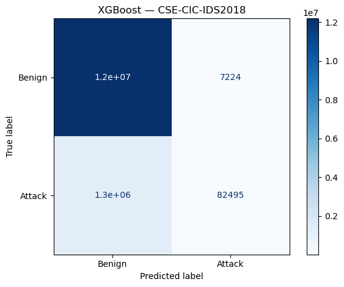

```
XGBoost → UNSW-NB15
Accuracy      : 0.9723
Precision     : 0.3366
Recall        : 0.0790
F1-score      : 0.1279
Macro F1      : 0.5569
MCC           : 0.1530
ROC-AUC       : 0.7362

              precision    recall  f1-score   support

      Benign       0.98      1.00      0.99   3389125
      Attack       0.34      0.08      0.13     89508

    accuracy                           0.97   3478633
   macro avg       0.66      0.54      0.56   3478633
weighted avg       0.96      0.97      0.96   3478633
```

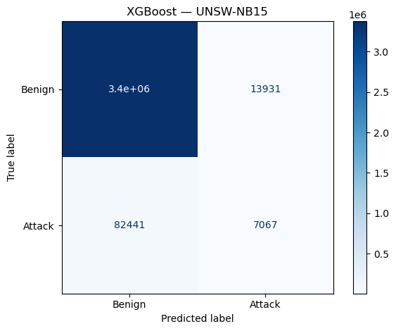

```python
results.append(evaluate_model("XGBoost", xgb_final, X_test1_tree, y_test1_tree, "CSE-CIC-IDS2018"))
results.append(evaluate_model("XGBoost", xgb_final, X_test2_tree, y_test2_tree, "UNSW-NB15"))
```

##### Training Deep Neural Network

```python
# DNN TUNING SUBSET

TUNING_SIZE = 300000

X_dnn_tune, _, y_dnn_tune, _ = train_test_split(
    X_train_dnn,
    y_train_dnn,
    train_size=TUNING_SIZE,
    stratify=y_train_dnn,
    random_state=42
)

X_dnn_tune_train, X_dnn_tune_val, y_dnn_tune_train, y_dnn_tune_val = train_test_split(
    X_dnn_tune,
    y_dnn_tune,
    test_size=0.20,
    stratify=y_dnn_tune,
    random_state=42
)

print("DNN tuning training shape:", X_dnn_tune_train.shape)
print("DNN tuning validation shape:", X_dnn_tune_val.shape)
```

```
DNN tuning training shape: (240000, 55)
DNN tuning validation shape: (60000, 55)
```

```python
# OPTUNA - DNN (F1 OPTIMIZATION)

def dnn_objective(trial):

    # Hyperparameters
    n_layers = trial.suggest_int(
        "n_layers", 2, 6
    )

    units = trial.suggest_categorical(
        "units",
        [64, 128, 256, 512]
    )

    dropout_rate = trial.suggest_float(
        "dropout_rate", 0.1, 0.5
    )

    learning_rate = trial.suggest_float(
        "learning_rate", 1e-4, 1e-2, log=True
    )

    batch_size = trial.suggest_categorical(
        "batch_size",
        [512, 1024, 2048, 4096]
    )

    # Build DNN
    model = keras.Sequential()

    model.add(
        keras.layers.Input(
            shape=(X_dnn_tune_train.shape[1],)
        )
    )

    for _ in range(n_layers):

        model.add(
            keras.layers.Dense(
                units,
                activation="relu"
            )
        )

        model.add(
            keras.layers.Dropout(
                dropout_rate
            )
        )

    model.add(
        keras.layers.Dense(
            1,
            activation="sigmoid"
        )
    )

    # Compile
    model.compile(
        optimizer=keras.optimizers.Adam(
            learning_rate=learning_rate
        ),
        loss="binary_crossentropy",
        metrics=["accuracy"]
    )

    # Train
    model.fit(
        X_dnn_tune_train,
        y_dnn_tune_train,
        validation_data=(
            X_dnn_tune_val,
            y_dnn_tune_val
        ),
        epochs=50,
        batch_size=batch_size,
        verbose=0
    )

    # Predictions
    y_prob = model.predict(
        X_dnn_tune_val,
        verbose=0
    ).ravel()

    y_pred = (
        y_prob >= 0.5
    ).astype(int)

    # Attack-class F1
    f1 = f1_score(
        y_dnn_tune_val,
        y_pred,
        zero_division=0
    )

    keras.backend.clear_session()

    return f1
```

```python
# CREATE DNN OPTUNA STUDY

dnn_study = optuna.create_study(
    direction="maximize",
    study_name="DNN_F1"
)

for _ in tqdm(range(30), desc="Optuna DNN Trials"):
    dnn_study.optimize(
        dnn_objective,
        n_trials=1,
        n_jobs=-1,
        show_progress_bar=True
    )
print("\nBest DNN F1:")
print(round(dnn_study.best_value, 4))

print("\nBest DNN parameters:")
print(dnn_study.best_params)
```

```
[I 2026-09-12 16:46:10,630] A new study created in memory with name: DNN_F1
```

```
WARNING:tensorflow:From C:\Users\Acer\anaconda3\envs\py311\Lib\site-packages\keras\src\backend\common\global_state.py:82: The name tf.reset_default_graph is deprecated. Please use tf.compat.v1.reset_default_graph instead.

[I 2026-09-12 16:48:30,219] Trial 0 finished with value: 0.00019409937888198756 and parameters: {'n_layers': 6, 'units': 128, 'dropout_rate': 0.457419882900053, 'learning_rate': 0.00020292373281768165, 'batch_size': 4096}. Best is trial 0 with value: 0.00019409937888198756.
```

```
[I 2026-09-12 16:50:27,979] Trial 1 finished with value: 0.6427206221577803 and parameters: {'n_layers': 3, 'units': 128, 'dropout_rate': 0.20907805421233472, 'learning_rate': 0.0016042829200683933, 'batch_size': 2048}. Best is trial 1 with value: 0.6427206221577803.
```

```
[I 2026-09-12 16:52:48,880] Trial 2 finished with value: 0.6484144179633642 and parameters: {'n_layers': 2, 'units': 128, 'dropout_rate': 0.19187475369285323, 'learning_rate': 0.008802630552042974, 'batch_size': 1024}. Best is trial 2 with value: 0.6484144179633642.
```

```
[I 2026-09-12 16:53:46,829] Trial 3 finished with value: 0.3038035244398373 and parameters: {'n_layers': 2, 'units': 64, 'dropout_rate': 0.24892741689954934, 'learning_rate': 0.0005060785080284723, 'batch_size': 4096}. Best is trial 2 with value: 0.6484144179633642.
```

```
[I 2026-09-12 16:54:44,310] Trial 4 finished with value: 0.6186383778702833 and parameters: {'n_layers': 2, 'units': 64, 'dropout_rate': 0.45567057531553645, 'learning_rate': 0.008731206568347704, 'batch_size': 4096}. Best is trial 2 with value: 0.6484144179633642.
```

```
[I 2026-09-12 16:59:17,546] Trial 5 finished with value: 0.6500131475151196 and parameters: {'n_layers': 2, 'units': 256, 'dropout_rate': 0.20810625118279563, 'learning_rate': 0.001040103985026427, 'batch_size': 512}. Best is trial 5 with value: 0.6500131475151196.
```

```
[I 2026-09-12 17:02:02,311] Trial 6 finished with value: 0.2688108336859924 and parameters: {'n_layers': 5, 'units': 128, 'dropout_rate': 0.46541677908864143, 'learning_rate': 0.0024613233872679495, 'batch_size': 2048}. Best is trial 5 with value: 0.6500131475151196.
```

```
[I 2026-09-12 17:04:17,078] Trial 7 finished with value: 0.0 and parameters: {'n_layers': 6, 'units': 64, 'dropout_rate': 0.4964967030651771, 'learning_rate': 0.0001301516139205839, 'batch_size': 2048}. Best is trial 5 with value: 0.6500131475151196.
```

```
[I 2026-09-12 17:10:51,263] Trial 8 finished with value: 0.6487233482495394 and parameters: {'n_layers': 6, 'units': 128, 'dropout_rate': 0.13816979685351738, 'learning_rate': 0.0008769753350444129, 'batch_size': 512}. Best is trial 5 with value: 0.6500131475151196.
```

```
[I 2026-09-12 17:14:22,084] Trial 9 finished with value: 0.6282611574625877 and parameters: {'n_layers': 2, 'units': 128, 'dropout_rate': 0.3277434479189741, 'learning_rate': 0.00015214274566945562, 'batch_size': 512}. Best is trial 5 with value: 0.6500131475151196.
```

```
[I 2026-09-12 17:21:42,689] Trial 10 finished with value: 0.6413669779455593 and parameters: {'n_layers': 4, 'units': 256, 'dropout_rate': 0.35131935620262966, 'learning_rate': 0.0037067952421761174, 'batch_size': 512}. Best is trial 5 with value: 0.6500131475151196.
```

```
[I 2026-09-12 17:29:03,413] Trial 11 finished with value: 0.646379298963628 and parameters: {'n_layers': 4, 'units': 256, 'dropout_rate': 0.10676260196757795, 'learning_rate': 0.0008088618874631522, 'batch_size': 512}. Best is trial 5 with value: 0.6500131475151196.
```

```
[I 2026-09-12 17:41:42,472] Trial 12 finished with value: 0.6512392347643153 and parameters: {'n_layers': 4, 'units': 512, 'dropout_rate': 0.11166684076148377, 'learning_rate': 0.0005274776962529035, 'batch_size': 512}. Best is trial 12 with value: 0.6512392347643153.
```

```
[I 2026-09-12 17:54:23,800] Trial 13 finished with value: 0.6491678179067166 and parameters: {'n_layers': 4, 'units': 512, 'dropout_rate': 0.16240797442196453, 'learning_rate': 0.0003414688507373862, 'batch_size': 512}. Best is trial 12 with value: 0.6512392347643153.
```

```
[I 2026-09-12 18:01:28,565] Trial 14 finished with value: 0.6486344192168476 and parameters: {'n_layers': 3, 'units': 512, 'dropout_rate': 0.26154739206909594, 'learning_rate': 0.0011556802616049125, 'batch_size': 1024}. Best is trial 12 with value: 0.6512392347643153.
```

```
[I 2026-09-12 18:07:58,327] Trial 15 finished with value: 0.649470290188853 and parameters: {'n_layers': 3, 'units': 256, 'dropout_rate': 0.10164112728942695, 'learning_rate': 0.0003749425380874855, 'batch_size': 512}. Best is trial 12 with value: 0.6512392347643153.
```

```
[I 2026-09-12 18:23:54,768] Trial 16 finished with value: 0.650085537570733 and parameters: {'n_layers': 5, 'units': 512, 'dropout_rate': 0.2590738317225534, 'learning_rate': 0.0005743120301757316, 'batch_size': 512}. Best is trial 12 with value: 0.6512392347643153.
```

```
[I 2026-09-12 18:39:58,046] Trial 17 finished with value: 0.6459415050936576 and parameters: {'n_layers': 5, 'units': 512, 'dropout_rate': 0.32623104871641156, 'learning_rate': 0.00025105341149047407, 'batch_size': 512}. Best is trial 12 with value: 0.6512392347643153.
```

```
[I 2026-09-12 18:51:09,614] Trial 18 finished with value: 0.6482405462184874 and parameters: {'n_layers': 5, 'units': 512, 'dropout_rate': 0.27232356393637036, 'learning_rate': 0.0005304151264604206, 'batch_size': 1024}. Best is trial 12 with value: 0.6512392347643153.
```

```
[I 2026-09-12 19:07:23,362] Trial 19 finished with value: 0.6475965016111002 and parameters: {'n_layers': 5, 'units': 512, 'dropout_rate': 0.3827644004160876, 'learning_rate': 0.0005842286160677091, 'batch_size': 512}. Best is trial 12 with value: 0.6512392347643153.
```

```
[I 2026-09-12 19:20:23,862] Trial 20 finished with value: 0.5797689033042773 and parameters: {'n_layers': 4, 'units': 512, 'dropout_rate': 0.4086973694657962, 'learning_rate': 0.00010084128303662832, 'batch_size': 512}. Best is trial 12 with value: 0.6512392347643153.
```

```
[I 2026-09-12 19:27:06,206] Trial 21 finished with value: 0.6506277525800302 and parameters: {'n_layers': 3, 'units': 256, 'dropout_rate': 0.21627195590041987, 'learning_rate': 0.0016818743318756484, 'batch_size': 512}. Best is trial 12 with value: 0.6512392347643153.
```

```
[I 2026-09-12 19:37:41,361] Trial 22 finished with value: 0.6489011712067377 and parameters: {'n_layers': 3, 'units': 512, 'dropout_rate': 0.2933275517929209, 'learning_rate': 0.0016738331195558268, 'batch_size': 512}. Best is trial 12 with value: 0.6512392347643153.
```

```
[I 2026-09-12 19:45:23,164] Trial 23 finished with value: 0.6454509441436683 and parameters: {'n_layers': 4, 'units': 256, 'dropout_rate': 0.16965569835750435, 'learning_rate': 0.0034302608919615273, 'batch_size': 512}. Best is trial 12 with value: 0.6512392347643153.
```

```
[I 2026-09-12 20:01:28,549] Trial 24 finished with value: 0.6498356344510191 and parameters: {'n_layers': 5, 'units': 512, 'dropout_rate': 0.23275335019980736, 'learning_rate': 0.0016327933932193117, 'batch_size': 512}. Best is trial 12 with value: 0.6512392347643153.
```

```
[I 2026-09-12 20:07:46,064] Trial 25 finished with value: 0.6463221724228843 and parameters: {'n_layers': 3, 'units': 256, 'dropout_rate': 0.14749440201282424, 'learning_rate': 0.00032308579442878597, 'batch_size': 512}. Best is trial 12 with value: 0.6512392347643153.
```

```
[I 2026-09-12 20:14:26,821] Trial 26 finished with value: 0.6364415156507414 and parameters: {'n_layers': 4, 'units': 512, 'dropout_rate': 0.28436606911234985, 'learning_rate': 0.000692878924726061, 'batch_size': 4096}. Best is trial 12 with value: 0.6512392347643153.
```

```
[I 2026-09-12 20:26:03,007] Trial 27 finished with value: 0.6458018278650799 and parameters: {'n_layers': 5, 'units': 512, 'dropout_rate': 0.2151092466024131, 'learning_rate': 0.004002421323380042, 'batch_size': 1024}. Best is trial 12 with value: 0.6512392347643153.
```

```
[I 2026-09-12 20:29:00,443] Trial 28 finished with value: 0.6506039915966386 and parameters: {'n_layers': 3, 'units': 256, 'dropout_rate': 0.12517912314822513, 'learning_rate': 0.00227581155390466, 'batch_size': 2048}. Best is trial 12 with value: 0.6512392347643153.
```

```
[I 2026-09-12 20:31:57,336] Trial 29 finished with value: 0.6487233482495394 and parameters: {'n_layers': 3, 'units': 256, 'dropout_rate': 0.13148111442020344, 'learning_rate': 0.005120464512449753, 'batch_size': 2048}. Best is trial 12 with value: 0.6512392347643153.

Best DNN F1:
0.6512

Best DNN parameters:
{'n_layers': 4, 'units': 512, 'dropout_rate': 0.11166684076148377, 'learning_rate': 0.0005274776962529035, 'batch_size': 512}
```

```python
# FINAL DNN

best_dnn_params = dnn_study.best_params

n_layers = best_dnn_params["n_layers"]
units = best_dnn_params["units"]
dropout_rate = best_dnn_params["dropout_rate"]
learning_rate = best_dnn_params["learning_rate"]

dnn_final = keras.Sequential()

dnn_final.add(
    keras.layers.Input(
        shape=(X_train_dnn.shape[1],)
    )
)

for _ in range(n_layers):

    dnn_final.add(
        keras.layers.Dense(
            units,
            activation="relu"
        )
    )

    dnn_final.add(
        keras.layers.Dropout(
            dropout_rate
        )
    )

dnn_final.add(
    keras.layers.Dense(
        1,
        activation="sigmoid"
    )
)

dnn_final.compile(
    optimizer=keras.optimizers.Adam(
        learning_rate=learning_rate
    ),
    loss="binary_crossentropy",
    metrics=["accuracy"]
)

dnn_final.summary()
```

```
Model: "sequential"
```

```
┏━━━━━━━━━━━━━━━━━━━━━━━━━━━━━━━━━┳━━━━━━━━━━━━━━━━━━━━━━━━┳━━━━━━━━━━━━━━━┓
┃ Layer (type)                    ┃ Output Shape           ┃       Param # ┃
┡━━━━━━━━━━━━━━━━━━━━━━━━━━━━━━━━━╇━━━━━━━━━━━━━━━━━━━━━━━━╇━━━━━━━━━━━━━━━┩
│ dense (Dense)                   │ (None, 512)            │        28,672 │
├─────────────────────────────────┼────────────────────────┼───────────────┤
│ dropout (Dropout)               │ (None, 512)            │             0 │
├─────────────────────────────────┼────────────────────────┼───────────────┤
│ dense_1 (Dense)                 │ (None, 512)            │       262,656 │
├─────────────────────────────────┼────────────────────────┼───────────────┤
│ dropout_1 (Dropout)             │ (None, 512)            │             0 │
├─────────────────────────────────┼────────────────────────┼───────────────┤
│ dense_2 (Dense)                 │ (None, 512)            │       262,656 │
├─────────────────────────────────┼────────────────────────┼───────────────┤
│ dropout_2 (Dropout)             │ (None, 512)            │             0 │
├─────────────────────────────────┼────────────────────────┼───────────────┤
│ dense_3 (Dense)                 │ (None, 512)            │       262,656 │
├─────────────────────────────────┼────────────────────────┼───────────────┤
│ dropout_3 (Dropout)             │ (None, 512)            │             0 │
├─────────────────────────────────┼────────────────────────┼───────────────┤
│ dense_4 (Dense)                 │ (None, 1)              │           513 │
└─────────────────────────────────┴────────────────────────┴───────────────┘
```

```
 Total params: 817,153 (3.12 MB)
```

```
 Trainable params: 817,153 (3.12 MB)
```

```
 Non-trainable params: 0 (0.00 B)
```

```python
# TRAIN FINAL DNN

best_batch_size = best_dnn_params["batch_size"]

print("Training final DNN...")

history_dnn = dnn_final.fit(
    X_train_dnn,
    y_train_dnn,
    validation_split=0.10,
    epochs=50,
    batch_size=best_batch_size,
    verbose=1
)

print("Final DNN training completed.")
```

```
Training final DNN...
4395/4395 ━━━━━━━━━━━━━━━━━━━━ 168s 37ms/step - accuracy: 0.8598 - loss: 7093.0454 - val_accuracy: 0.9668 - val_loss: 0.3424
4395/4395 ━━━━━━━━━━━━━━━━━━━━ 173s 39ms/step - accuracy: 0.9026 - loss: 1.1186 - val_accuracy: 0.9672 - val_loss: 0.4838
4395/4395 ━━━━━━━━━━━━━━━━━━━━ 154s 35ms/step - accuracy: 0.9031 - loss: 1.7859 - val_accuracy: 0.9673 - val_loss: 0.3458
4395/4395 ━━━━━━━━━━━━━━━━━━━━ 171s 39ms/step - accuracy: 0.9043 - loss: 2.5043 - val_accuracy: 0.9666 - val_loss: 1.4633
4395/4395 ━━━━━━━━━━━━━━━━━━━━ 187s 43ms/step - accuracy: 0.9041 - loss: 3.2818 - val_accuracy: 0.9674 - val_loss: 0.9163
4395/4395 ━━━━━━━━━━━━━━━━━━━━ 166s 38ms/step - accuracy: 0.9043 - loss: 0.8901 - val_accuracy: 0.9655 - val_loss: 1.0138
4395/4395 ━━━━━━━━━━━━━━━━━━━━ 189s 43ms/step - accuracy: 0.9041 - loss: 1.3034 - val_accuracy: 0.9652 - val_loss: 0.4207
4395/4395 ━━━━━━━━━━━━━━━━━━━━ 178s 40ms/step - accuracy: 0.9043 - loss: 4.9769 - val_accuracy: 0.9674 - val_loss: 0.9322
4395/4395 ━━━━━━━━━━━━━━━━━━━━ 187s 42ms/step - accuracy: 0.9046 - loss: 6.5532 - val_accuracy: 0.9649 - val_loss: 1.2116
4395/4395 ━━━━━━━━━━━━━━━━━━━━ 188s 43ms/step - accuracy: 0.9046 - loss: 4.4459 - val_accuracy: 0.9661 - val_loss: 1.1720
4395/4395 ━━━━━━━━━━━━━━━━━━━━ 172s 39ms/step - accuracy: 0.9041 - loss: 7.4485 - val_accuracy: 0.9671 - val_loss: 1.5228
4395/4395 ━━━━━━━━━━━━━━━━━━━━ 172s 39ms/step - accuracy: 0.9046 - loss: 3.2042 - val_accuracy: 0.9671 - val_loss: 1.8673
4395/4395 ━━━━━━━━━━━━━━━━━━━━ 174s 40ms/step - accuracy: 0.9044 - loss: 5.7175 - val_accuracy: 0.9669 - val_loss: 3.3692
4395/4395 ━━━━━━━━━━━━━━━━━━━━ 176s 40ms/step - accuracy: 0.9045 - loss: 1.4762 - val_accuracy: 0.9651 - val_loss: 2.3308
4395/4395 ━━━━━━━━━━━━━━━━━━━━ 168s 38ms/step - accuracy: 0.9043 - loss: 0.9313 - val_accuracy: 0.9656 - val_loss: 2.6307
4395/4395 ━━━━━━━━━━━━━━━━━━━━ 181s 41ms/step - accuracy: 0.9045 - loss: 3.4781 - val_accuracy: 0.9673 - val_loss: 6.3371
4395/4395 ━━━━━━━━━━━━━━━━━━━━ 178s 41ms/step - accuracy: 0.9045 - loss: 1.5423 - val_accuracy: 0.9675 - val_loss: 4.1604
4395/4395 ━━━━━━━━━━━━━━━━━━━━ 179s 41ms/step - accuracy: 0.9045 - loss: 1.8303 - val_accuracy: 0.9657 - val_loss: 4.7300
4395/4395 ━━━━━━━━━━━━━━━━━━━━ 182s 41ms/step - accuracy: 0.9047 - loss: 1.3342 - val_accuracy: 0.9672 - val_loss: 4.0367
4395/4395 ━━━━━━━━━━━━━━━━━━━━ 180s 41ms/step - accuracy: 0.9045 - loss: 2.8064 - val_accuracy: 0.9640 - val_loss: 7.9039
4395/4395 ━━━━━━━━━━━━━━━━━━━━ 178s 41ms/step - accuracy: 0.9045 - loss: 4.7021 - val_accuracy: 0.9646 - val_loss: 7.3895
4395/4395 ━━━━━━━━━━━━━━━━━━━━ 185s 42ms/step - accuracy: 0.9048 - loss: 3.0973 - val_accuracy: 0.9672 - val_loss: 6.4364
4395/4395 ━━━━━━━━━━━━━━━━━━━━ 185s 42ms/step - accuracy: 0.9046 - loss: 4.0367 - val_accuracy: 0.9669 - val_loss: 10.8930
4395/4395 ━━━━━━━━━━━━━━━━━━━━ 193s 44ms/step - accuracy: 0.9049 - loss: 2.7283 - val_accuracy: 0.9658 - val_loss: 9.6974
4395/4395 ━━━━━━━━━━━━━━━━━━━━ 195s 44ms/step - accuracy: 0.9048 - loss: 10.6790 - val_accuracy: 0.9673 - val_loss: 12.1806
4395/4395 ━━━━━━━━━━━━━━━━━━━━ 199s 45ms/step - accuracy: 0.9046 - loss: 1.8616 - val_accuracy: 0.9671 - val_loss: 17.4087
4395/4395 ━━━━━━━━━━━━━━━━━━━━ 216s 49ms/step - accuracy: 0.9049 - loss: 1.6037 - val_accuracy: 0.9669 - val_loss: 17.0558
4395/4395 ━━━━━━━━━━━━━━━━━━━━ 217s 49ms/step - accuracy: 0.9048 - loss: 1.1414 - val_accuracy: 0.9670 - val_loss: 20.8720
4395/4395 ━━━━━━━━━━━━━━━━━━━━ 217s 49ms/step - accuracy: 0.9047 - loss: 3.0476 - val_accuracy: 0.9671 - val_loss: 18.6541
4395/4395 ━━━━━━━━━━━━━━━━━━━━ 214s 49ms/step - accuracy: 0.9047 - loss: 1.5860 - val_accuracy: 0.9685 - val_loss: 29.3700
4395/4395 ━━━━━━━━━━━━━━━━━━━━ 227s 52ms/step - accuracy: 0.9048 - loss: 1.7347 - val_accuracy: 0.9665 - val_loss: 19.8065
4395/4395 ━━━━━━━━━━━━━━━━━━━━ 227s 51ms/step - accuracy: 0.9044 - loss: 3.2119 - val_accuracy: 0.9671 - val_loss: 30.6427
4395/4395 ━━━━━━━━━━━━━━━━━━━━ 248s 56ms/step - accuracy: 0.9047 - loss: 2.6920 - val_accuracy: 0.9679 - val_loss: 24.4294
```

[output cut: 18 more lines]

##### DNN Evaluation

```
Deep Neural Network → CSE-CIC-IDS2018
Accuracy      : 0.9058
Precision     : 0.9824
Recall        : 0.0584
F1-score      : 0.1102
Macro F1      : 0.5302
MCC           : 0.2274
ROC-AUC       : 0.5470

              precision    recall  f1-score   support

      Benign       0.91      1.00      0.95  12196127
      Attack       0.98      0.06      0.11   1353464

    accuracy                           0.91  13549591
   macro avg       0.94      0.53      0.53  13549591
weighted avg       0.91      0.91      0.87  13549591
```

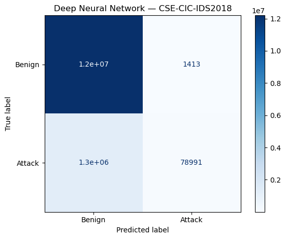

```
Deep Neural Network → UNSW-NB15
Accuracy      : 0.9360
Precision     : 0.0025
Recall        : 0.0038
F1-score      : 0.0030
Macro F1      : 0.4850
MCC           : -0.0293
ROC-AUC       : 0.7923

              precision    recall  f1-score   support

      Benign       0.97      0.96      0.97   3389125
      Attack       0.00      0.00      0.00     89508

    accuracy                           0.94   3478633
   macro avg       0.49      0.48      0.48   3478633
weighted avg       0.95      0.94      0.94   3478633
```

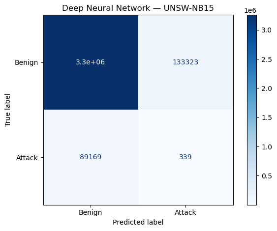

```python
results.append(evaluate_model("Deep Neural Network", dnn_final, X_test1_dnn, y_test1_dnn, "CSE-CIC-IDS2018", is_keras=True))
results.append(evaluate_model("Deep Neural Network", dnn_final, X_test2_dnn, y_test2_dnn, "UNSW-NB15", is_keras=True))
```

##### Model Comparison

```python
results_df = pd.DataFrame(results)
print(results_df)
```

```
                 Model     Test Dataset  Accuracy  Precision  Recall  \
0        Random Forest  CSE-CIC-IDS2018     0.916      0.955   0.170
1        Random Forest        UNSW-NB15     0.974      0.333   0.000
2              XGBoost  CSE-CIC-IDS2018     0.906      0.919   0.061
3              XGBoost        UNSW-NB15     0.972      0.337   0.079
4  Deep Neural Network  CSE-CIC-IDS2018     0.906      0.982   0.058
5  Deep Neural Network        UNSW-NB15     0.936      0.003   0.004

   F1-score  Macro F1  ROC-AUC    MCC
0     0.288     0.622    0.849  0.383
1     0.000     0.494    0.701  0.007
2     0.114     0.532    0.915  0.223
3     0.128     0.557    0.736  0.153
4     0.110     0.530    0.547  0.227
5     0.003     0.485    0.792 -0.029
```

#### Saving the trained models

```python
import joblib

#Random Forest
joblib.dump(rf_final, "rf_model1.pkl")

#XGBoost
joblib.dump(xgb_final, "xgb_model1.pkl")

#RobustScaler
joblib.dump(scaler, "scaler1.pkl")

#DNN
dnn_final.save("dnn_model1.keras")

print("All Models for binary-labels saved successfully....")
```

```
All Models for binary-labels saved successfully....
```